# Trabajo Practico Regresión Avanzada

Regresión Lineal Simple

Jose Valdes

2023-06-05

```r
#limpio la memoria
rm( list= ls(all.names= TRUE) )  #remove all objects
gc( full= TRUE )                 #garbage collection
```

```
##          used (Mb) gc trigger (Mb) max used (Mb)
## Ncells 513315 27.5    1144491 61.2   644245 34.5
## Vcells 924638  7.1    8388608 64.0  1635137 12.5
```

Se realiza validación de la instalación de los paquetes necesarios para ejecutar el script

```r
# Bibliotecas a cargar

check_packages <- function(packages) {
  if (all(packages %in% rownames(installed.packages()))) {
    TRUE
  } else{
    cat(
      "Instalar los siguientes packages antes de ejecutar el presente script\n",
      packages[!(packages %in% rownames(installed.packages()))],
      "\n"
    )
  }
}
packages_needed <- c("readxl","ggplot2","MVN","gridExtra","aod","MASS","carData","car")

# Se llama a la funcion check_packages
check_packages(packages_needed)
```

```
## [1] TRUE
```

```r
library(readxl)
library(ggplot2)
library(MVN)
library(gridExtra)
library(aod)
library(MASS)
library(carData)
library(car)
```

# 1.1. Correlación

## Ejercicio 1.1.

En el archivo grasacerdos.xlsx se encuentran los datos del peso vivo (PV, en Kg) y al espesor de grasa dorsal (EGD, en mm) de 30 lechones elegidos al azar de una población de porcinos Duroc Jersey del Oeste de la provincia de Buenos Aires. Se pide

### (a)

Dibujar el diagrama de dispersión e interpretarlo.

```r
library(readxl)
library(ggplot2)
library(MVN)
library(gridExtra)

grasacerdos<-read_excel("C:/Users/Josvaldes/Documents/Maestria/Austral/1ano/regresionAvanzada/TPRegresion/TPRegresion/grasacerdos.xlsx")
dim(grasacerdos)
```

```
## [1] 30  3
```

```r
head(grasacerdos)
```

| Obs | PV | EGD |
| --- | --- | --- |
| 1 | 56,81 | 16,19 |
| 2 | 70,40 | 22,00 |
| 3 | 71,73 | 19,52 |
| 4 | 75,10 | 31,00 |
| 5 | 79,65 | 23,58 |
| 6 | 51,43 | 16,58 |

```r
grasacerdos$PV <- as.numeric(gsub(",", ".", grasacerdos$PV))
grasacerdos$EGD <- as.numeric(gsub(",", ".", grasacerdos$EGD))
```

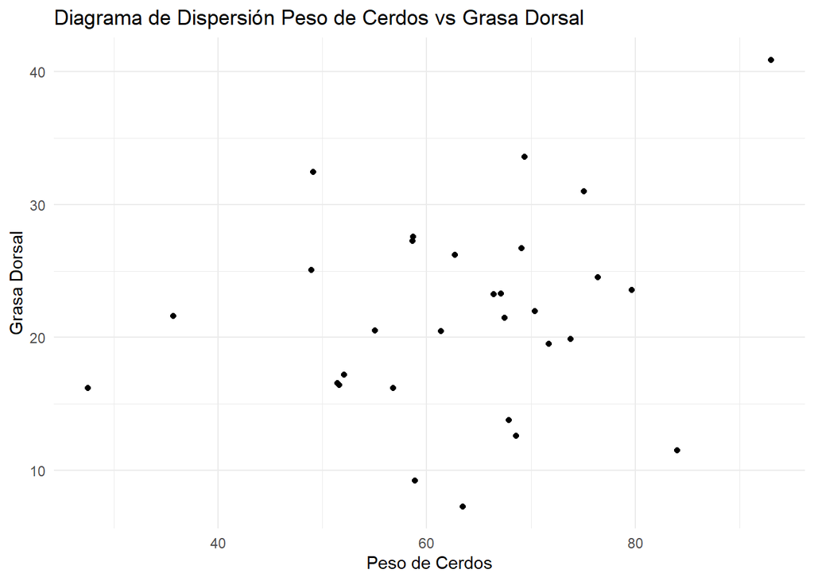

```r
ggplot(grasacerdos, aes(PV, EGD)) +
  geom_point() +
  theme_minimal() +
  labs(x = "Peso de Cerdos", y = "Grasa Dorsal",
       title = ("Diagrama de Dispersi\u00F3n Peso de Cerdos vs Grasa Dorsal")) # se deja la letra "ó" con \u00F3, que                                                                             es la representación Unicode de esa letra
```

No se observa corelación entre las variables

### (b)

Calcular el coeficiente de correlación muestral y explíquelo.

```r
biNormTest <- mvn(grasacerdos, mvnTest = "hz")
print(biNormTest$multivariateNormality)
```

```
##            Test        HZ   p value MVN
## 1 Henze-Zirkler 0.6379234 0.3891766 YES
```

Por el resultado se puede sostener el supuesto de una distribución normal bivariada para estas variables. En tal sentido, se procede a realizar el test de Pearson para determinar la relación de las variables:

```r
corCoeff <- cor(grasacerdos$PV,grasacerdos$EGD, method = "pearson")
corCoeff
```

```
## [1] 0.2543434
```

La prueba de correlación de Pearson muestra que existe una correlación positiva débil entre las variables. Esto significa que hay una tendencia a que los valores de las variables aumenten juntos, pero la relación no es muy fuerte.

### (c)

¿Hay suficiente evidencia para admitir asociación entre el peso y el espesor de grasa? (α = 0,05). Verifique los supuestos para decidir el indicador que va a utilizar.

Para determinar si hay suficiente evidencia para admitir una asociación entre el peso y el espesor de grasa, es necesario verificar los supuestos y luego utilizar un indicador apropiado para evaluar la correlación entre las variables.

A continuación, se describen los supuestos que se deben verificar antes de seleccionar el indicador:

1 - Supuesto de normalidad: Se debe verificar si las variables peso y espesor de grasa siguen una distribución normal. Esto se puede hacer mediante métodos gráficos, como histogramas o gráficos de Q-Q, y pruebas estadísticas, como el test de normalidad (por ejemplo, el test de Shapiro-Wilk).

```r
shapiro.test(grasacerdos$PV)
```

```
##
##  Shapiro-Wilk normality test
##
## data:  grasacerdos$PV
## W = 0.97533, p-value = 0.6925
```

```r
shapiro.test(grasacerdos$EGD)
```

```
##
##  Shapiro-Wilk normality test
##
## data:  grasacerdos$EGD
## W = 0.98514, p-value = 0.9395
```

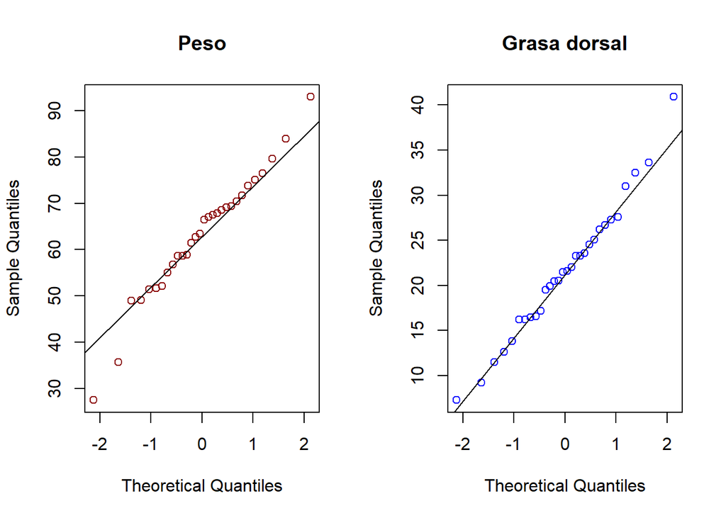

```r
par(mfrow = c(1, 2))
qqnorm(grasacerdos$PV, main = "Peso", col = "darkred")
qqline(grasacerdos$PV)
qqnorm(grasacerdos$EGD, main = "Grasa dorsal", col = "blue")
qqline(grasacerdos$EGD)
```

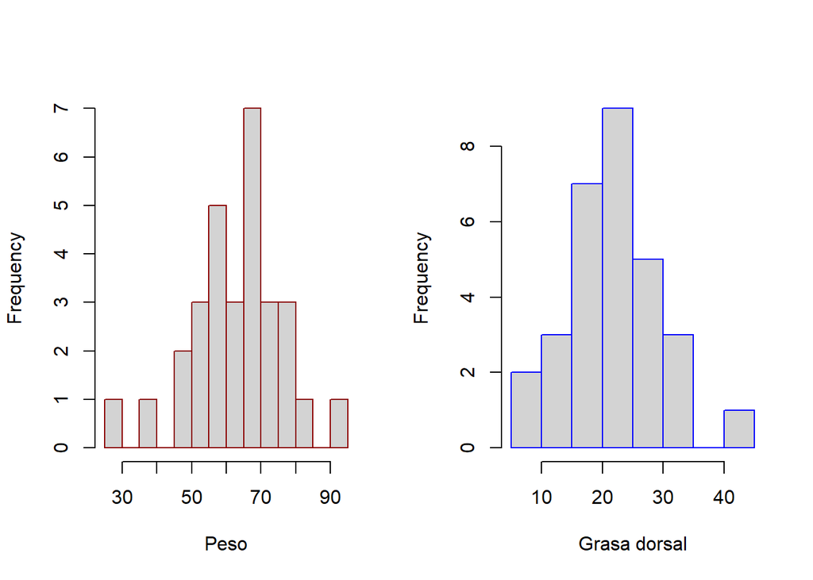

```r
par(mfrow = c(1, 2))
hist(grasacerdos$PV, breaks = 10, main = "", xlab = "Peso", border = "darkred")
hist(grasacerdos$EGD, breaks = 10, main = "", xlab = "Grasa dorsal", border = "blue")
```

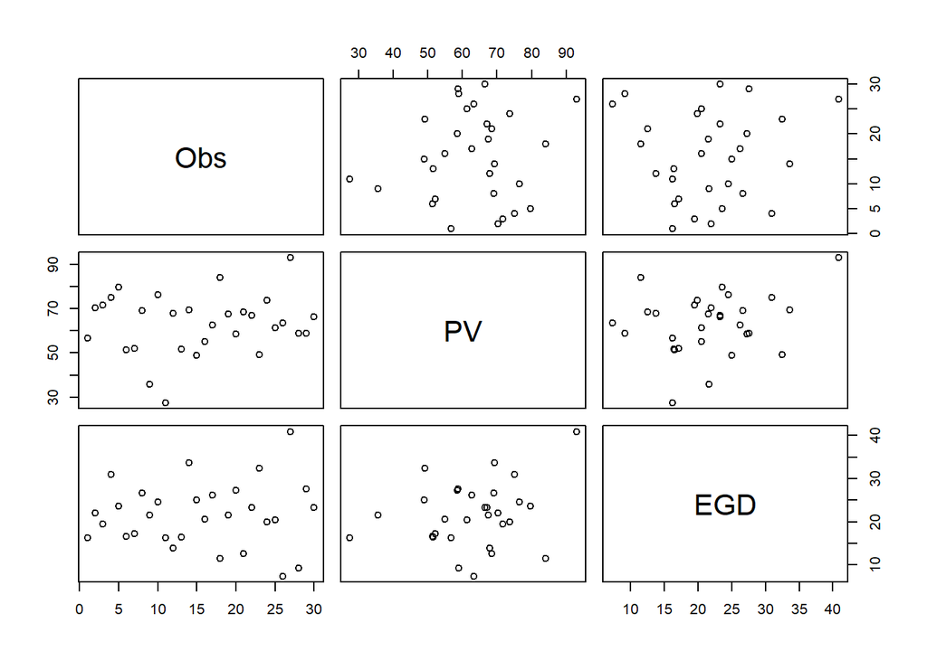

```r
par(bg="white")
pairs(grasacerdos) # representa todos los diagramas de dispersión de a pares
```

2 - Supuesto de linealidad: Se debe verificar si la relación entre el peso y el espesor de grasa es lineal. Esto se puede explorar mediante un diagrama de dispersión o mediante técnicas de análisis exploratorio de datos.

3 - Supuesto de homogeneidad de varianzas: Se debe verificar si la varianza del espesor de grasa es constante en diferentes niveles de peso. Esto se puede evaluar mediante gráficos de dispersión y pruebas estadísticas, como el test de Levene.

Una vez que se han verificado los supuestos, puedes seleccionar un indicador apropiado para evaluar la asociación entre el peso y el espesor de grasa. Dado que estamos analizando una relación entre dos variables continuas, el coeficiente de correlación de Pearson sería un indicador adecuado.

Para determinar si hay suficiente evidencia para admitir la asociación entre el peso y el espesor de grasa, se puede realizar una prueba de hipótesis utilizando el coeficiente de correlación de Pearson. El enunciado de las hipótesis sería:

Hipótesis nula (H0): No hay asociación entre el peso y el espesor de grasa (ρ = 0). Hipótesis alternativa (HA): Hay asociación entre el peso y el espesor de grasa (ρ ≠ 0).

```r
corTest <- cor.test(grasacerdos$PV,grasacerdos$EGD, method = "pearson")
corTest
```

```
##
##  Pearson's product-moment correlation
##
## data:  grasacerdos$PV and grasacerdos$EGD
## t = 1.3916, df = 28, p-value = 0.175
## alternative hypothesis: true correlation is not equal to 0
## 95 percent confidence interval:
##  -0.1166112  0.5630217
## sample estimates:
##       cor
## 0.2543434
```

El resultado del test de correlación de Pearson como se mostró en el punto b corresponde a una correlacion positiva baja entre las variables y un P-valor de 0.1749942 que seria mayor que el nivel de significancia $\alpha$ = 0,05 de la prueba, por tal razon, no se puede afirmar la presencia de una asociación significativa entre las variables.

## Ejercicio 1.2.

Los datos del cuarteto de Anscombe se encuentran en el archivo anscombe.xlsx

Se pide explorar los datos de la siguiente manera:

### (a)

Graficar los cuatro pares de datos en un diagrama de dispersión cada uno.

```r
# se observa que el archivo esta incompleto anscombe.xlsx (dimensiones 6x8), se busca en internet y se trabaja con Anscombe's Quartet.xlsx (dimensiones 12x8)
anscombe<-read_excel("C:/Users/Josvaldes/Documents/Maestria/Austral/1ano/regresionAvanzada/TPRegresion/TPRegresion/Anscombe's Quartet.xlsx")
dim(anscombe)
```

```
## [1] 11  8
```

```r
head(anscombe)
```

| X1 | X2 | X3 | X4 | X5 | X6 | X7 | X8 |
| --- | --- | --- | --- | --- | --- | --- | --- |
| 10 | 8.04 | 10 | 9.14 | 10 | 7.46 | 8 | 6.58 |
| 8 | 6.95 | 8 | 8.14 | 8 | 6.77 | 8 | 5.76 |
| 13 | 7.58 | 13 | 8.74 | 13 | 12.74 | 8 | 7.71 |
| 9 | 8.81 | 9 | 8.77 | 9 | 7.11 | 8 | 8.84 |
| 11 | 8.33 | 11 | 9.26 | 11 | 7.81 | 8 | 8.47 |
| 14 | 9.96 | 14 | 8.10 | 14 | 8.84 | 8 | 7.04 |

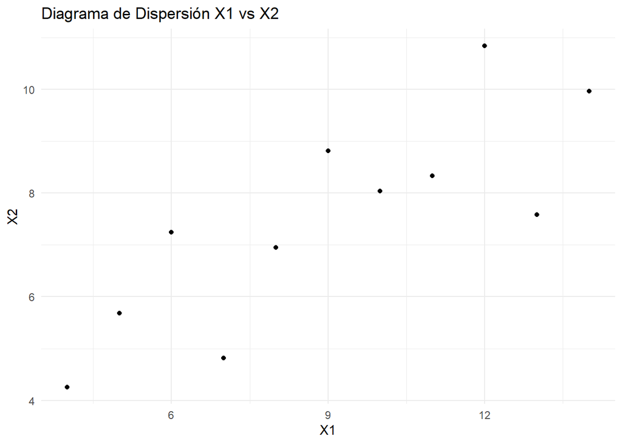

```r
dd1=ggplot(anscombe, aes(X1, X2)) +
  geom_point() + theme_minimal() + labs(title = "Diagrama de Dispersi\u00F3n X1 vs X2")
dd1
```

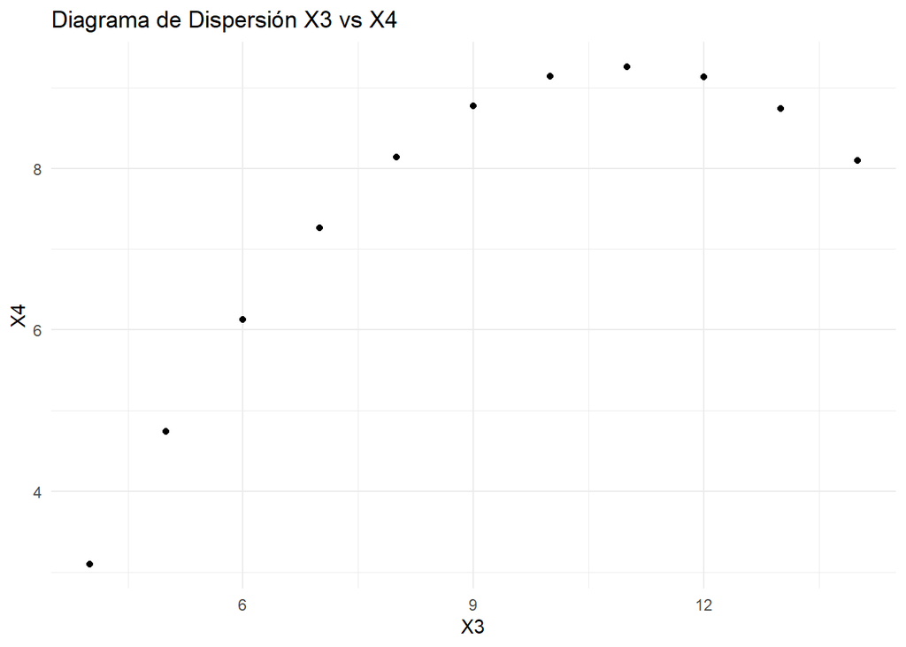

```r
dd2=ggplot(anscombe, aes(X3, X4)) +
  geom_point() + theme_minimal() + labs(title = "Diagrama de Dispersi\u00F3n X3 vs X4")
dd2
```

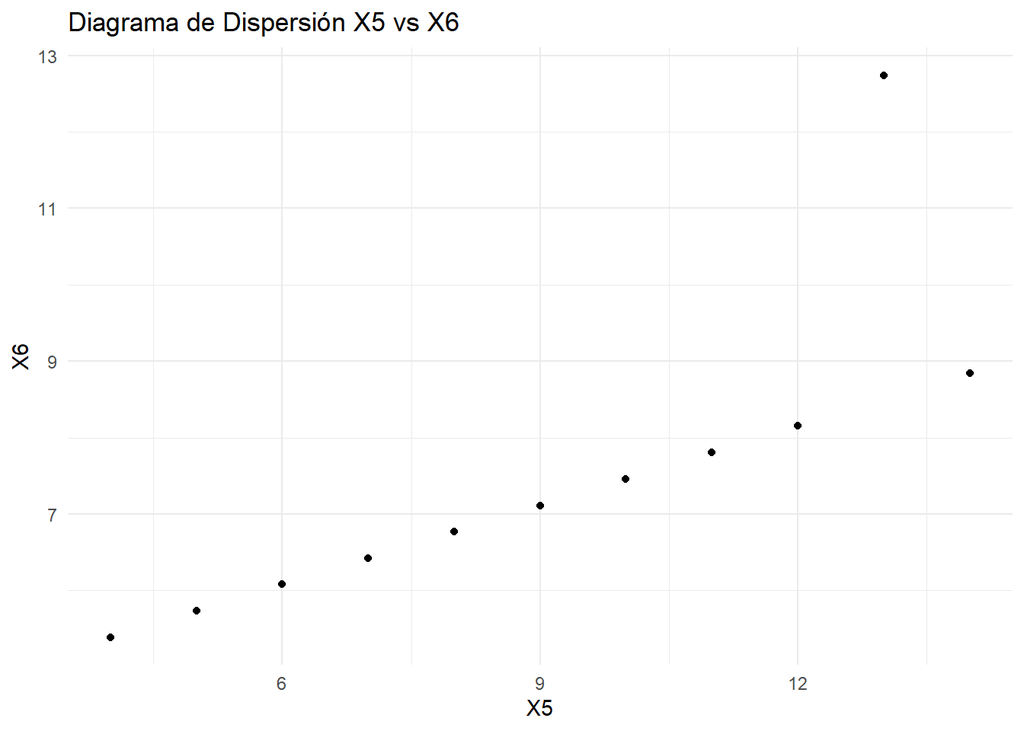

```r
dd3=ggplot(anscombe, aes(X5, X6)) +
  geom_point() + theme_minimal() + labs(title = "Diagrama de Dispersi\u00F3n X5 vs X6")
dd3
```

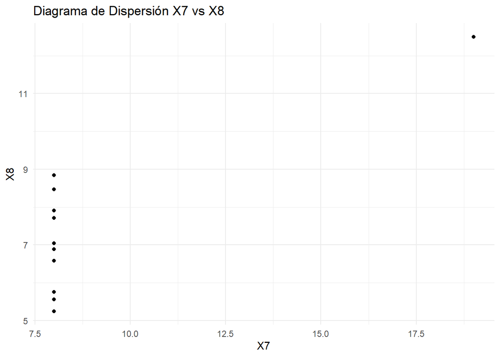

```r
dd4=ggplot(anscombe, aes(X7, X8)) +
  geom_point() + theme_minimal() + labs(title = "Diagrama de Dispersi\u00F3n X7 vs X8")
dd4
```

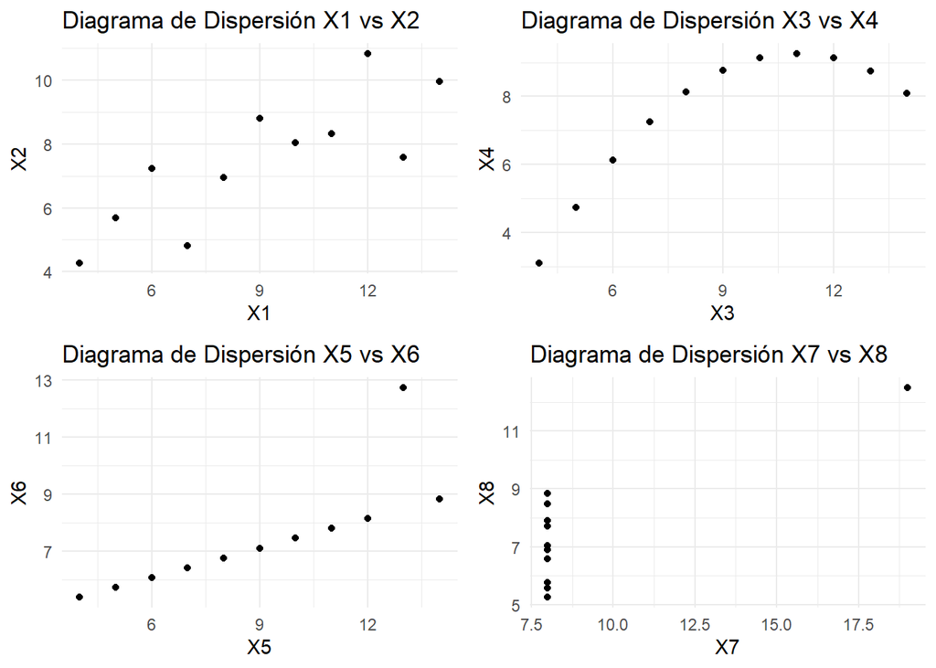

```r
#resumen
grid.arrange(dd1,dd2,dd3,dd4, ncol = 2, nrow = 2)
```

### (b)

Hallar los valores medios de las variables para cada par de datos.

```r
colMeans(anscombe)
```

```
##       X1       X2       X3       X4       X5       X6       X7       X8
## 9.000000 7.500909 9.000000 7.500909 9.000000 7.500000 9.000000 7.500909
```

### (c)

Hallar los valores de la dispersión para cada conjunto de datos.

```r
sapply(anscombe, sd)
```

```
##       X1       X2       X3       X4       X5       X6       X7       X8
## 3.316625 2.031568 3.316625 2.031657 3.316625 2.030424 3.316625 2.030579
```

### (d)

Hallar el coeficiente muestral de correlación lineal en cada caso.

```r
mvn(data = anscombe[c(1,2)], mvnTest = "hz")$multivariateNormality$MVN
```

```
## [1] "YES"
```

```r
mvn(data = anscombe[c(3,4)], mvnTest = "hz")$multivariateNormality$MVN
```

```
## [1] "NO"
```

```r
mvn(data = anscombe[c(5,6)], mvnTest = "hz")$multivariateNormality$MVN
```

```
## [1] "NO"
```

```r
mvn(data = anscombe[c(7,8)], mvnTest = "hz")$multivariateNormality$MVN
```

```
## [1] "NO"
```

```r
cor.test(anscombe$X1,anscombe$X2,method="pearson")$p.value
```

```
## [1] 0.002169629
```

```r
cor.test(anscombe$X3,anscombe$X4,method="spearman")$p.value
```

```
## [1] 0.02305887
```

```r
cor.test(anscombe$X5,anscombe$X6,method="spearman")$p.value
```

```
## [1] 0
```

```r
cor.test(anscombe$X7,anscombe$X8,method="spearman")$p.value
```

```
## Warning in cor.test.default(anscombe$X7, anscombe$X8, method = "spearman"):
## Cannot compute exact p-value with ties
```

```
## [1] 0.1173068
```

```r
cor.test(anscombe$X7,anscombe$X8,method="pearson")$p.value
```

```
## [1] 0.002164602
```

### (e)

Observar, comentar y concluir.

Por los resultados obtenidos en el primer par de variables se utiliza el coeficiente de correlación de Pearson y para los tres paredes restantes el de Spearman. Aunque para la relación de variables X7 y X8 aunque se obtuvo con test de Henze-Zirkler como resultado NO, se recibe una warning por el cual se hace la prueba con el test de Pearson.

# 1.2. Modelo Lineal Simple

## Ejercicio 1.3.

El archivo peso_edad_colest.xlsx disponible contiene registros correspondientes a 25 individuos respecto de su peso, su edad y el nivel de colesterol total en sangre.

Se pide:

### (a)

Realizar el diagrama de dispersión de colesterol en función de la edad y de colesterol en función de peso. Le parece adecuado ajustar un modelo lineal para alguno de estos dos pares de variables?

```r
#Se cargan los datos
colesterol <- read_excel('peso_edad_colest.xlsx')

#Se visualizan la estructura
head(colesterol)
```

| peso | edad | colest |
| --- | --- | --- |
| 84 | 46 | 354 |
| 73 | 20 | 190 |
| 65 | 52 | 405 |
| 70 | 30 | 263 |
| 76 | 57 | 451 |
| 69 | 25 | 302 |

Se realizan los diagramas de dispersión solicitados

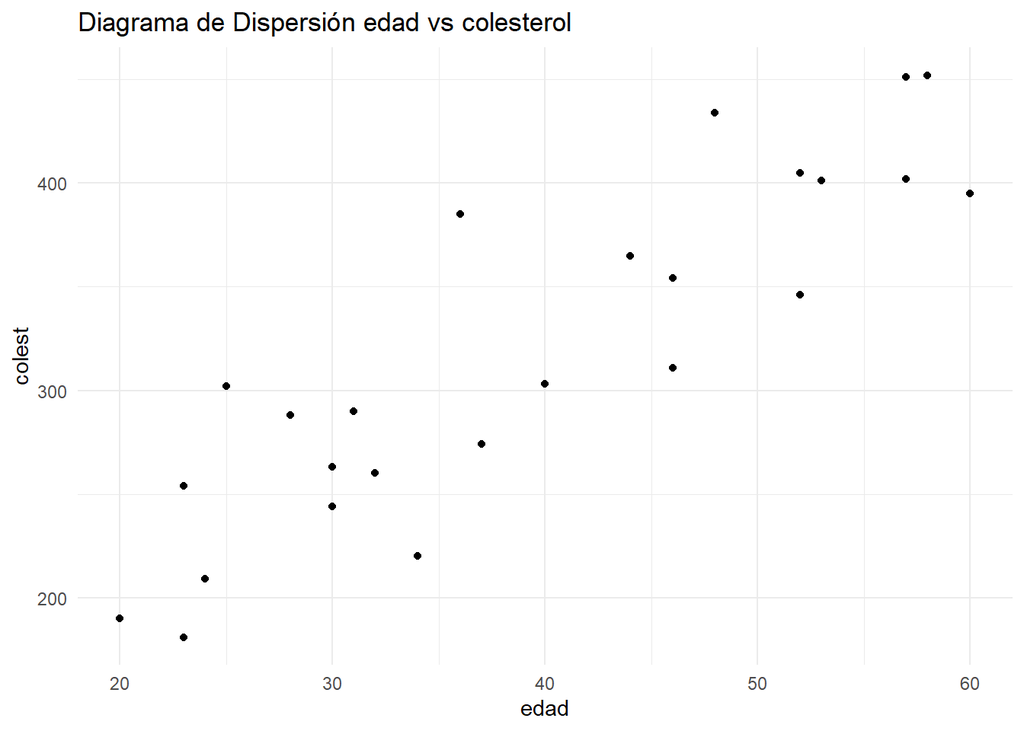

```r
#Diagrama de dispersión colesterol en función de la edad
dd112=ggplot(colesterol, aes(edad, colest)) +
  geom_point() + theme_minimal() + labs(title = "Diagrama de Dispersi\u00F3n edad vs colesterol")
dd112
```

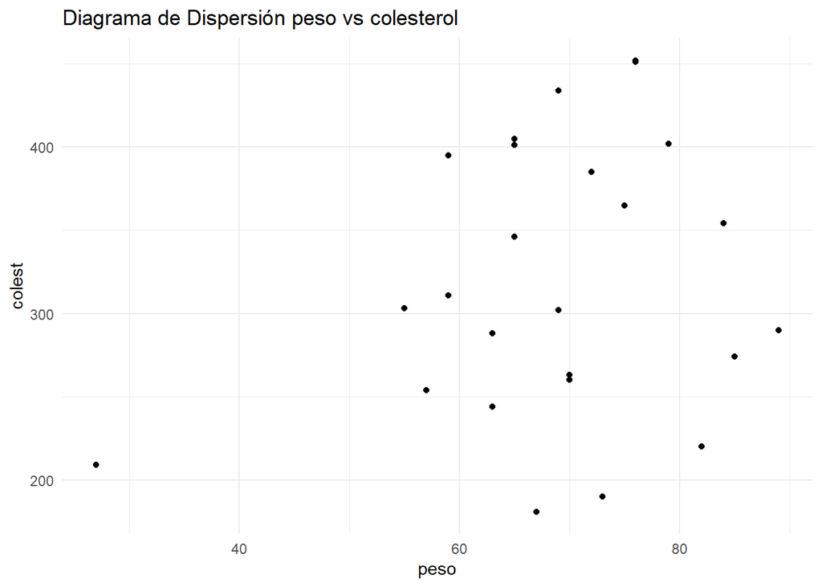

```r
#Diagrama de dispersión colesterol en función del peso
dd212=ggplot(colesterol, aes(peso, colest)) +
  geom_point() + theme_minimal() + labs(title = "Diagrama de Dispersi\u00F3n peso vs colesterol")
dd212
```

Por las gráficas se podría pensar que se ajuste un modelo lineal entre las variables edad y colesterol.

### (b)

Estime los coeficientes del modelo lineal para el colesterol en función de la edad.

Coeficientes

```r
#Modelo lineal para el colesterol en función de la edad.
model <- lm(colest ~ edad, data = colesterol)
model$coefficients
```

```
## (Intercept)        edad
##   95.502004    5.670842
```

Grafica del modelo y las bandas de error estándar alrededor de la línea de regresión

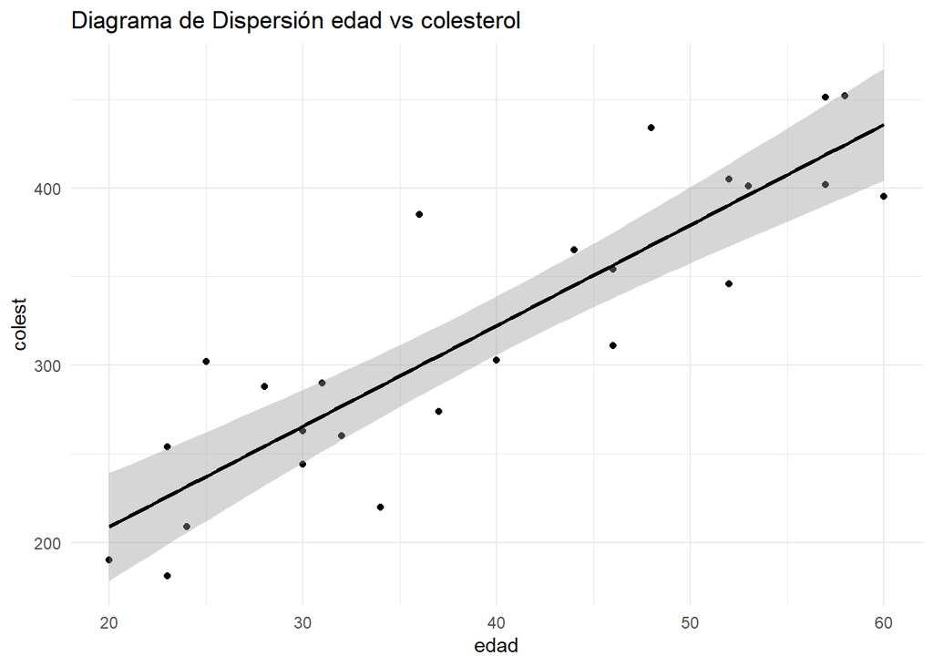

```r
(dd112+ geom_smooth(method = "lm", se = TRUE, color = "black") )
```

### (c)

Estime intervalos de confianza del 95% para los coeficientes del modelo y compare estos resultados con el test de Wald para los coeficientes. Le parece que hay asociación entre estos test y el test de la regresión?

```r
ic <- confint(model, level = 0.95)
ic
```

```
##                 2.5 %     97.5 %
## (Intercept) 41.190390 149.813618
## edad         4.358216   6.983467
```

Test de Wald

```r
library(aod)
coef(model)
```

```
## (Intercept)        edad
##   95.502004    5.670842
```

```r
testWald=wald.test(Sigma = vcov(model), b = coef(model), Terms = 1)
testWald
```

```
## Wald test:
## ----------
##
## Chi-squared test:
## X2 = 13.2, df = 1, P(> X2) = 0.00028
```

Las anteriores salidas muestra los coeficientes estimados del modelo de regresión lineal y los resultados del test de Wald para evaluar la significancia de los coeficientes.

Los coeficientes del modelo indican lo siguiente:

- El coeficiente de intercepto (Intercept) es de aproximadamente 95.502004.
- El coeficiente para la variable “edad” es de aproximadamente 5.670842.

El test de Wald se utiliza para evaluar la significancia estadística de los coeficientes del modelo. En este caso, se realiza el test de Wald para el coeficiente del intercepto (intercept). El resultado del test muestra que el estadístico de prueba chi-cuadrado (X2) es de 13.2, con 1 grado de libertad y un valor p (P(>X2)) de 0.00028.

Se puede concluir lo siguiente:

El coeficiente de intercepto es significativamente diferente de cero, debido a que el valor p es muy pequeño (0.00028). Esto indica que hay evidencia de una asociación entre la variable de respuesta y la variable de intercepto.

En cuanto al coeficiente de la variable “edad”, se realizan los siguientes cancululos para obtener el test de wald:

```r
# Se obtiene la matriz de varianza-covarianza de los coeficientes del modelo
vcov_model <- vcov(model)

# Se obtienen los coeficientes estimados del modelo
coef_model <- coef(model)

# Calculo del estadístico de prueba utilizando la fórmula del test de Wald:
wald_stat <- (coef_model["edad"] - 0) / sqrt(vcov_model["edad", "edad"])

# Calculo del valor p correspondiente al estadístico de prueba
p_value <- 1 - pchisq(wald_stat^2, df = 1)

# Imprimir resultado
cat("Test de Wald para la variable 'edad':\n")
```

```
## Test de Wald para la variable 'edad':
```

```r
cat("------------------------\n")
cat("Estadístico de prueba:", wald_stat, "\n")
```

```
## Estadístico de prueba: 8.937073
```

```r
cat("Valor p:", p_value, "\n")
```

```
## Valor p: 0
```

En resumen, hay evidencia de asociación entre el coeficiente de intercepto y la variable de respuesta según el test de Wald.Para la variable “edad” se tiene un estadístico de prueba de 8.937073 y un valor p de 0. Esto indica que hay evidencia significativa para rechazar la hipótesis nula de que el coeficiente de “edad” sea igual a cero.

### (d)

A partir de esta recta estime los valores de E(Y ) para x = 25 años y x = 48 años. Podría estimarse el valor de E(Y ) para x = 80 años?

Para estimar los valores de E(Y) para diferentes valores de x utilizando la recta ajustada en el modelo de regresión, se pueden utilizar los coeficientes del modelo.

En este caso, los coeficientes del modelo son:

Intercepto: 95.502004 Coeficiente para la variable “edad”: 5.670842

E(Y) = Intercepto + Coeficiente * x

```r
predict(model, newdata = data.frame(edad = c(25,80)))
```

```
##        1        2
## 237.2730 549.1693
```

Sin embargo, para valores de x más allá del rango de los datos observados, como x = 80 años, la extrapolación puede no ser confiable. La recta ajustada se basa en los datos observados y su validez puede estar limitada a ese rango. Por lo tanto, no se recomienda estimar el valor de E(Y) para x = 80 años utilizando este modelo de regresión.

### (e)

Testee la normalidad de los residuos y haga un gráfico para ver si son homocedásticos.

```r
# Prueba de normalidad de Shapiro-Wilk
residuos <- residuals(model)
shapiro.test(residuos)
```

```
##
##  Shapiro-Wilk normality test
##
## data:  residuos
## W = 0.96478, p-value = 0.5175
```

El resultado de esta prueba proporciona un valor p que indica que no hay suficiente evidencia para rechazar la hipótesis nula de normalidad de los residuos. Como el valor p es mayor que un umbral de significancia (por ejemplo, 0.05), se puede concluir que los residuos siguen una distribución normal.

Grafico de los residuos del modelo

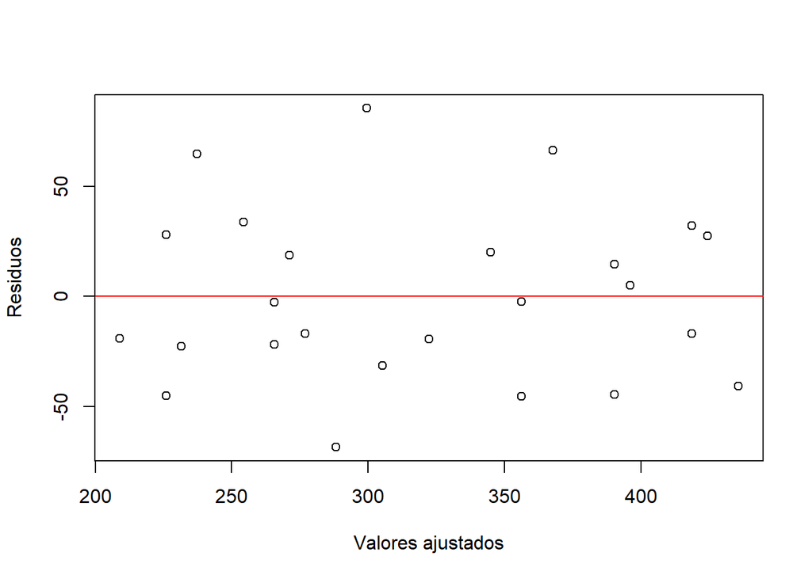

```r
plot(residuos ~ fitted.values(model), ylab = "Residuos", xlab = "Valores ajustados")
abline(h = 0, col = "red")
```

Grafico con lineas:

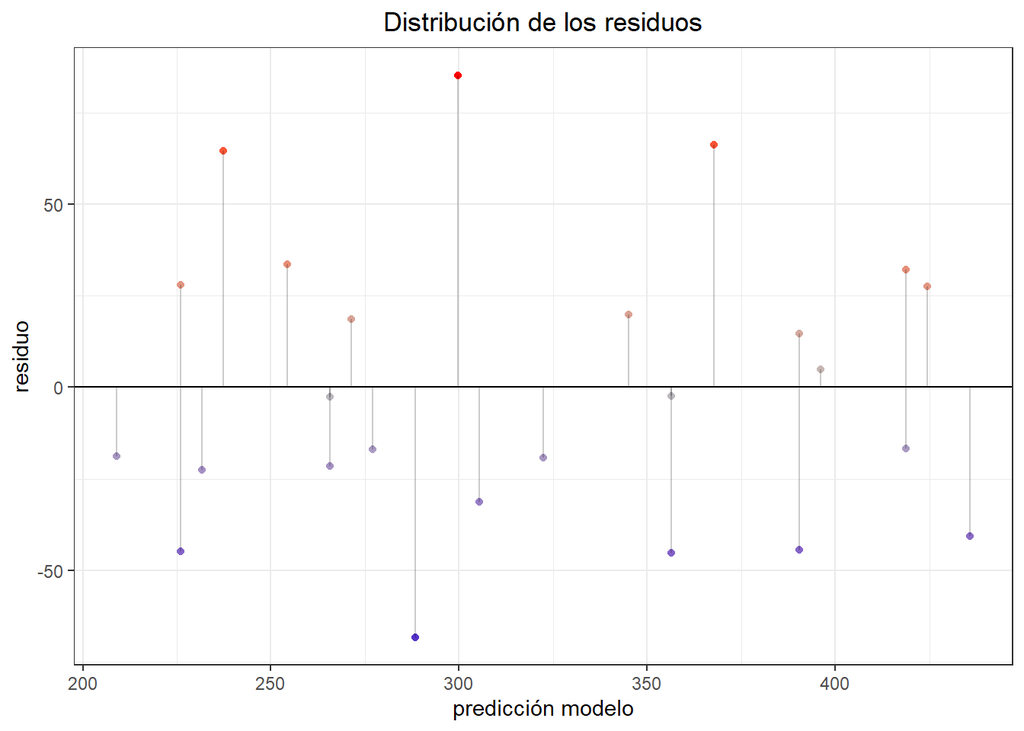

```r
colest2<-colesterol
colest2$prediccion <- model$fitted.values
colest2$residuos <- model$residuals

ggplot(data = colest2, aes(x = prediccion, y = residuos)) +
  geom_point(aes(color = residuos)) +
  scale_color_gradient2(low = "blue3", mid = "grey", high = "red") +
  geom_hline(yintercept = 0) + geom_segment(aes(xend = prediccion, yend = 0), alpha = 0.2) +
  labs(title = "Distribución de los residuos", x = "predicción modelo", y = "residuo") +
  theme_bw() +
  theme(plot.title = element_text(hjust = 0.5), legend.position = "none")
```

Grafico con histograma:

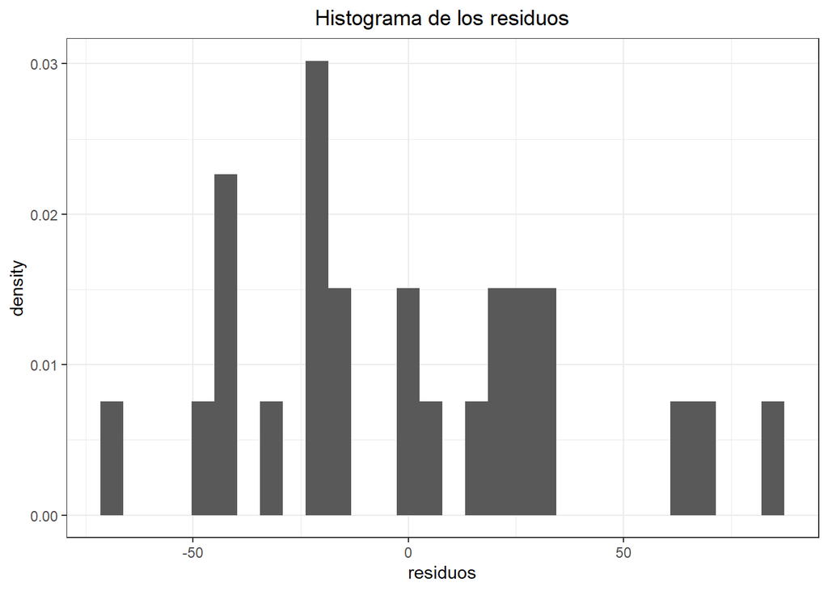

```r
ggplot(data = colest2, aes(x = residuos)) + geom_histogram(aes(y = after_stat(density))) +
  labs(title = "Histograma de los residuos") + theme_bw() +
  theme(plot.title = element_text(hjust = 0.5))
```

Grafico QQ

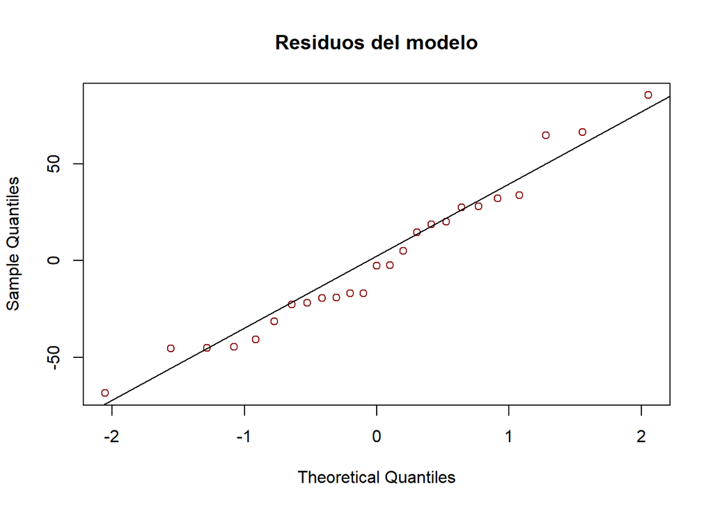

```r
qqnorm(model$residuals, main = "Residuos del modelo", col = "darkred")
qqline(model$residuals)
```

# 1.3. Transformación de Variables

## Ejercicio 1.4.

Una empresa desarrolló un sistema de energía solar para calentar el agua para una caldera que es parte del sistema de energía del proceso productivo. Existe el interés de controlar la estabilidad del sistema, para ello se monitorea el mismo y se registran los datos cada hora. Los datos se encuentran disponibles en el archivo energia.xlsx

### (a)

Realizar el diagrama de dispersión y evaluar si un modelo de regresión lineal es adecuado.

```r
# Se cargan los datos
energia <- read_excel('energia.xlsx')

#Se visualizan la estructura
head(energia)
```

| Hora | Energía |
| --- | --- |
| 1 | 598 |
| 2 | 527 |
| 3 | 530 |
| 4 | 528 |
| 5 | 452 |
| 6 | 497 |

```r
#Dimensiones
dim(energia)
```

```
## [1] 48  2
```

Diagrama de dispersión

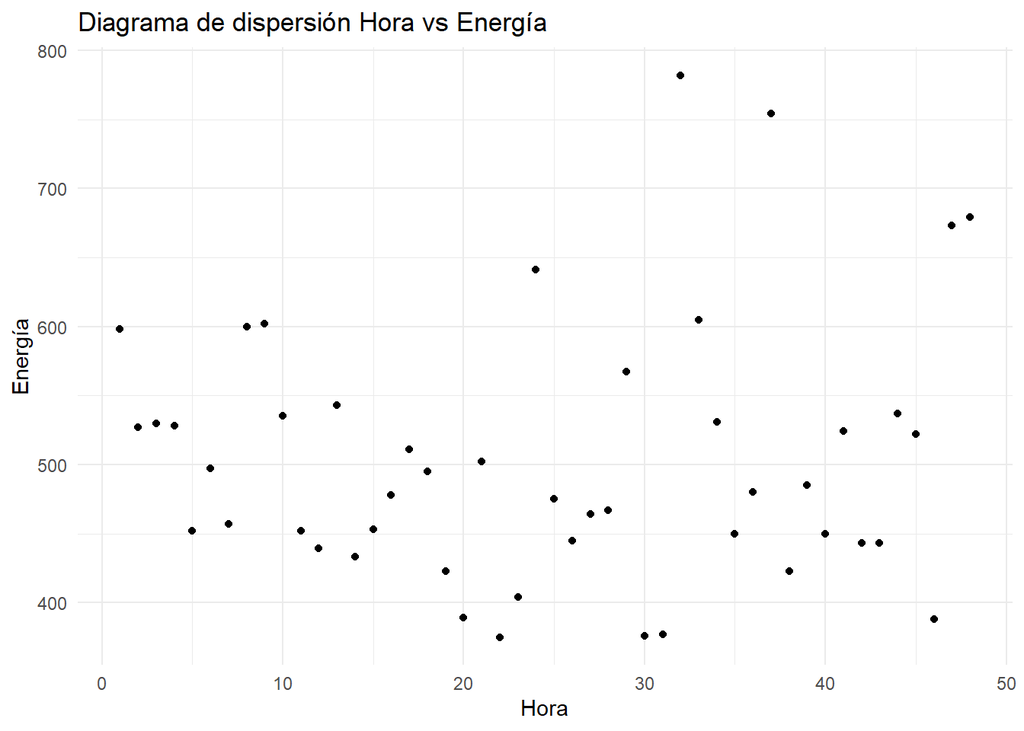

```r
#Diagrama de dispersión colesterol en función del peso
dd14=ggplot(energia, aes(Hora, Energía)) +
  geom_point() + theme_minimal() + labs(title = "Diagrama de dispersi\u00F3n Hora vs Energía")
dd14
```

```r
# Validación de una distribución normal bivariada para estas variables
biNormTest14 <- mvn(energia, mvnTest = "hz")
biNormTest14
```

```
## $multivariateNormality
##            Test       HZ     p value MVN
## 1 Henze-Zirkler 1.355059 0.002347283  NO
##
## $univariateNormality
##               Test  Variable Statistic   p value Normality
## 1 Anderson-Darling   Hora       0.5128    0.1849    YES
## 2 Anderson-Darling  Energía     1.1299    0.0053    NO
##
## $Descriptives
##          n   Mean  Std.Dev Median Min Max   25th   75th     Skew   Kurtosis
## Hora    48  24.50 14.00000   24.5   1  48  12.75  36.25 0.000000 -1.2752179
## Energía 48 504.25 93.07615  482.5 375 782 444.50 535.50 1.032494  0.8324672
```

Por arrojar un resultado de MVN NO se realiza el test de Spearman

```r
cor.test(energia$Hora,energia$Energía,method="spearman")$p.value
```

```
## [1] 0.806419
```

```r
# métodos robustos para manejar empates
cor.test(energia$Hora, energia$Energía, method = "spearman", exact = FALSE)
```

```
##
##  Spearman's rank correlation rho
##
## data:  energia$Hora and energia$Energía
## S = 19093, p-value = 0.8064
## alternative hypothesis: true rho is not equal to 0
## sample estimates:
##         rho
## -0.03631528
```

La salida corresponde a la prueba de correlación de rangos de Spearman y se puede interpretar de la siguiente manera:

- La primera línea indica que se realizó la prueba de correlación de rangos de Spearman en los datos de las variables “Hora” y “Energía” del dataframe “energia”.
- El valor de S es 19093, que es la suma de los cuadrados de las diferencias entre los rangos de las dos variables.
- El valor p es 0.8064, que es el valor p obtenido de la prueba de hipótesis. En este caso, como el valor p es mayor que 0.05 (nivel de significancia comúnmente utilizado), no hay suficiente evidencia para rechazar la hipótesis nula de que no hay correlación entre las dos variables.
- La hipótesis alternativa indica que el verdadero coeficiente de correlación rho no es igual a cero.
- La estimación de rho basada en la muestra es -0.03631528, lo que indica una correlación negativa muy débil entre las dos variables.

En resumen, la salida sugiere que no hay evidencia suficiente para concluir que hay una correlación significativa entre las variables “Hora” y “Energía” en el conjunto de datos analizado.

### (b)

Estimar un modelo lineal y verificar la normalidad de los residuos del mismo.

```r
model14 = lm(Energía ~ Hora, data=energia)
summary(model14)
```

```
##
## Call:
## lm(formula = Energía ~ Hora, data = energia)
##
## Residuals:
##     Min      1Q  Median      3Q     Max
## -131.12  -60.60  -24.31   37.29  273.84
##
## Coefficients:
##             Estimate Std. Error t value Pr(>|t|)
## (Intercept) 491.4894    27.5044  17.869   <2e-16 ***
## Hora          0.5208     0.9772   0.533    0.597
## ---
## Signif. codes:  0 '***' 0.001 '**' 0.01 '*' 0.05 '.' 0.1 ' ' 1
##
## Residual standard error: 93.79 on 46 degrees of freedom
## Multiple R-squared:  0.006138,   Adjusted R-squared:  -0.01547
## F-statistic: 0.2841 on 1 and 46 DF,  p-value: 0.5966
```

El modelo de regresión lineal ajustado es el siguiente:

Energía = 491.4894 + 0.5208 * Hora

Se interpreta:

El valor t de 0.533 y el correspondiente valor p de 0.597 indican que el coeficiente de la variable “Hora” no es estadísticamente significativo, es decir, no hay suficiente evidencia para afirmar que hay una relación lineal significativa entre la variable “Hora” y la variable “Energía”.

El modelo en general muestra un ajuste deficiente, ya que el valor del R-cuadrado ajustado es negativo (-0.01547), lo que indica que el modelo no explica bien la variabilidad de los datos. Además, el valor p asociado al estadístico F es de 0.5966, lo que sugiere que el modelo en su conjunto no es estadísticamente significativo.

En resumen, el modelo de regresión lineal no muestra una relación significativa entre la variable “Hora” y la variable “Energía”, y no es capaz de explicar la variabilidad en los datos de manera satisfactoria.

### (c)

En caso de rechazar este supuesto buscar una transformación lineal para este modelo y aplicarla.

```r
library(MASS)

# Aplica la transformación de Box-Cox a la variable dependiente "Energía" en función de la variable independiente "Hora"
box_cox_result <- boxcox(Energía ~ Hora, lambda = -5:2, data = energia)
```

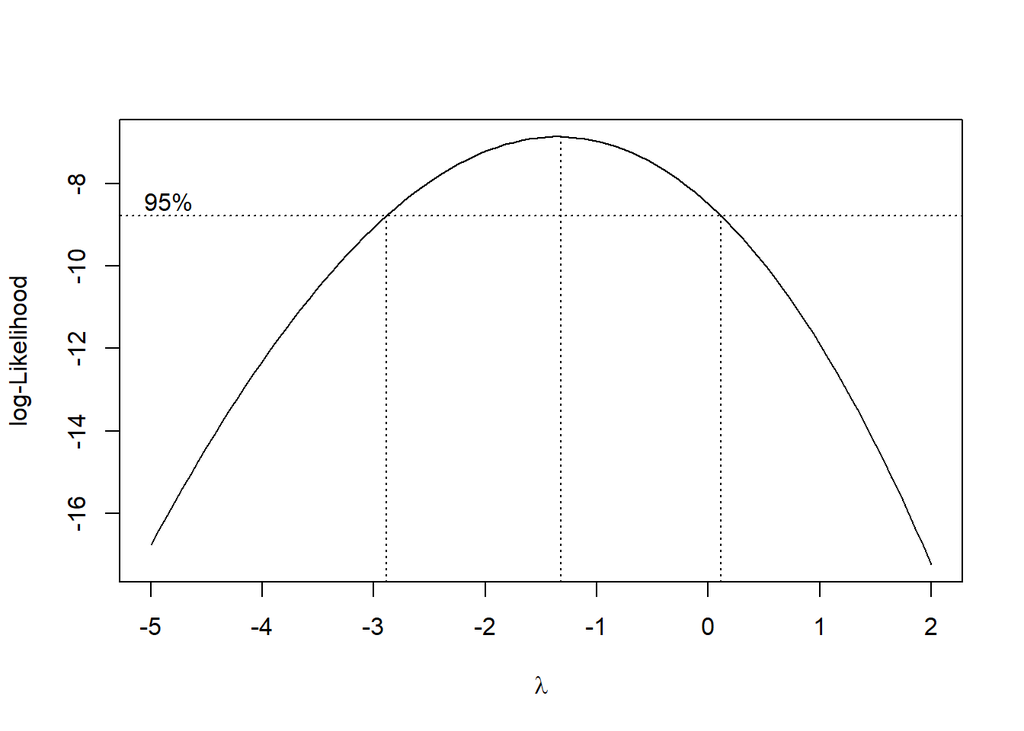

Según el gráfico, el lambda óptimo se encuentra cerca de -1. Entonces consideraremos la transformación de potencia sobre la variable respuesta.

```r
# Se encuentra el valor óptimo de lambda que maximiza el logaritmo de verosimilitud
best_box_cox <- box_cox_result$x[which.max(box_cox_result$y)]

# Se ajusta un modelo de regresión lineal utilizando la variable dependiente "Energía" elevada a la potencia óptima de lambda (best_box_cox) como la variable de respuesta y la variable independiente "Hora".
modelE2 <- lm((Energía)^(best_box_cox) ~ Hora, data = energia)

summary(modelE2)
```

```
##
## Call:
## lm(formula = (Energía)^(best_box_cox) ~ Hora, data = energia)
##
## Residuals:
##        Min         1Q     Median         3Q        Max
## -1.290e-04 -3.263e-05  3.849e-06  3.599e-05  1.150e-04
##
## Coefficients:
##               Estimate Std. Error t value Pr(>|t|)
## (Intercept)  2.779e-04  1.787e-05   15.55   <2e-16 ***
## Hora        -1.251e-08  6.350e-07   -0.02    0.984
## ---
## Signif. codes:  0 '***' 0.001 '**' 0.01 '*' 0.05 '.' 0.1 ' ' 1
##
## Residual standard error: 6.094e-05 on 46 degrees of freedom
## Multiple R-squared:  8.444e-06,  Adjusted R-squared:  -0.02173
## F-statistic: 0.0003884 on 1 and 46 DF,  p-value: 0.9844
```

```r
shapiro.test(modelE2$residuals)
```

```
##
##  Shapiro-Wilk normality test
##
## data:  modelE2$residuals
## W = 0.98002, p-value = 0.5796
```

Interpretación:

- El coeficiente del intercepto (Intercept) es 2.779e-04, lo cual representa el valor esperado de la variable de respuesta cuando la variable predictora es igual a cero. El coeficiente de la variable predictora “Hora” es -1.251e-08, lo que indica que hay una relación muy débil y casi nula entre la variable “Hora” y la variable de respuesta “Energía”.
- El coeficiente de determinación (R-cuadrado) múltiple es extremadamente bajo, con un valor de 8.444e-06. Esto indica que el modelo solo explica una fracción muy pequeña de la variabilidad de los datos de la variable de respuesta. El R-cuadrado ajustado tiene un valor negativo de -0.02173, lo que sugiere que el modelo no se ajusta bien a los datos.
- El valor del estadístico F es de 0.0003884 con un p-value asociado de 0.9844. Esto indica que el modelo en su conjunto no es estadísticamente significativo, lo que sugiere que no hay evidencia suficiente para afirmar que el modelo es una mejora significativa sobre un modelo nulo.
- La prueba de normalidad de Shapiro-Wilk se utiliza para evaluar si los residuos del modelo siguen una distribución normal. En este caso, el valor de W obtenido es 0.98002, y el p-value asociado es 0.5796. Como el p-value es mayor que 0.05, no hay suficiente evidencia para rechazar la hipótesis nula de normalidad de los residuos.

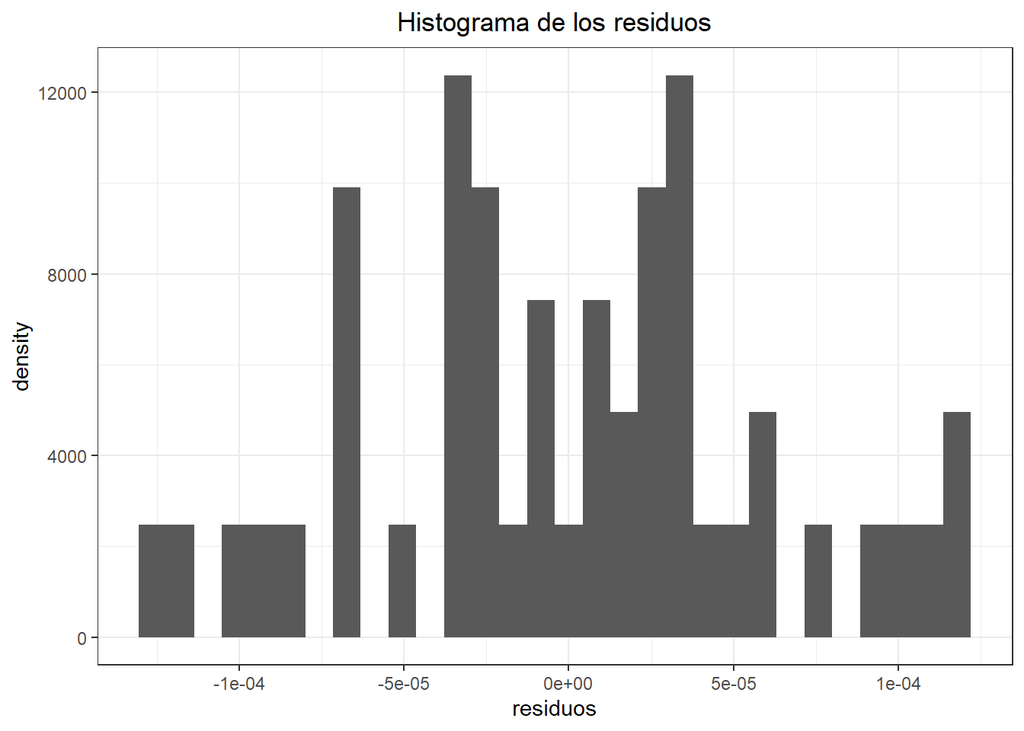

```r
# Crea una copia
energia3<-energia

# Se calcula el logaritmo natural de la columna "Energía" en el dataframe energia y se asigna a la columna "Energía" en energia3.
energia3$Energía <- log(energia$Energía)

# Se agrega una columna llamada "prediccion" en energia3 que contiene los valores ajustados del modelo modelE2.
energia3$prediccion <- modelE2$fitted.values

# Se agrega una columna llamada "residuos" en energia3 que contiene los residuos del modelo modelE2.
energia3$residuos <- modelE2$residuals

# Se crea un gráfico de histograma de los residuos utilizando la librería ggplot. Los residuos se representan en el eje x y la densidad en el eje y.
ggplot(data = energia3, aes(x = residuos)) + geom_histogram(aes(y = ..density..)) +
  labs(title = "Histograma de los residuos") + theme_bw() +
  theme(plot.title = element_text(hjust = 0.5))
```

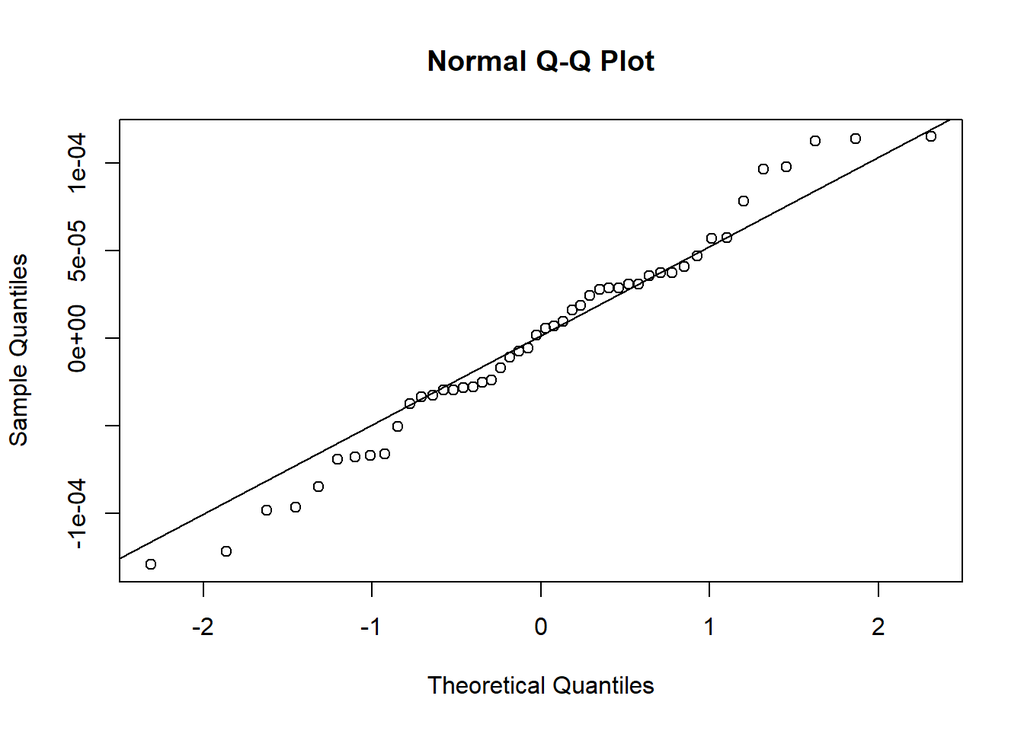

```r
# Se crea un gráfico de cuantiles normales (QQ plot) de los residuos del modelo modelE2.
qqnorm(modelE2$residuals)

# Se crea una linea de referencia en el grafico
qqline(modelE2$residuals)
```

```r
linMod2 <- lm(log10(Energía) ~ Hora, data = energia)
summary(linMod2)
```

```
##
## Call:
## lm(formula = log10(Energía) ~ Hora, data = energia)
##
## Residuals:
##      Min       1Q   Median       3Q      Max
## -0.12212 -0.04859 -0.01411  0.03415  0.19541
##
## Coefficients:
##              Estimate Std. Error t value Pr(>|t|)
## (Intercept) 2.6899875  0.0224064 120.055   <2e-16 ***
## Hora        0.0002440  0.0007961   0.306    0.761
## ---
## Signif. codes:  0 '***' 0.001 '**' 0.01 '*' 0.05 '.' 0.1 ' ' 1
##
## Residual standard error: 0.07641 on 46 degrees of freedom
## Multiple R-squared:  0.002038,   Adjusted R-squared:  -0.01966
## F-statistic: 0.09393 on 1 and 46 DF,  p-value: 0.7606
```

Los valores de t-value y p-value para el coeficiente de Hora son 0.306 y 0.761 respectivamente. Esto indica que no hay evidencia significativa para afirmar que la variable Hora tenga un efecto significativo en el logaritmo en base 10 de la variable Energía.

El R cuadrado múltiple ajustado es de -0.01966, lo que sugiere que el modelo no explica de manera efectiva la variabilidad en el logaritmo en base 10 de la variable Energía.

El F-estadístico tiene un valor de 0.09393 y un p-value de 0.7606. Esto indica que el modelo en su conjunto no es estadísticamente significativo.

En resumen, los resultados sugieren que el modelo de regresión lineal con la variable Hora como predictor no es adecuado para explicar la variabilidad en el logaritmo en base 10 de la variable Energía. No se encontró una relación significativa entre estas dos variables.

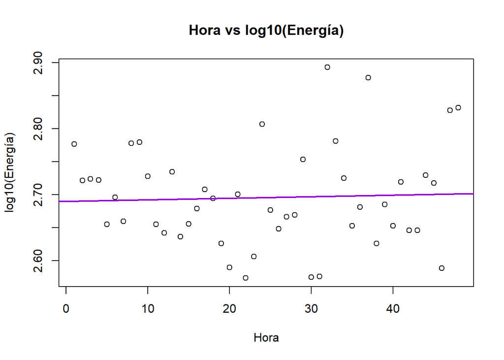

```r
plot(energia$Hora,log10(energia$Energía),xlab="Hora",ylab="log10(Energía)",
     main="Hora vs log10(Energía)")

abline(linMod2,col="darkviolet",lwd=2)
```

### (d)

Realizar el análisis diagnóstico del nuevo modelo y estimar un intervalo de confianza y un intervalo de predicción para 27.5 hs con ambos modelos. Comparar los intervalos.

análisis diagnóstico

```r
shapiro.test(linMod2$residuals)
```

```
##
##  Shapiro-Wilk normality test
##
## data:  linMod2$residuals
## W = 0.96393, p-value = 0.1454
```

W (estadístico de prueba): El valor de W obtenido es 0.96393. Este valor se utiliza para evaluar la desviación de la normalidad. Un valor cercano a 1 indica que los datos se ajustan bien a una distribución normal.

p-value (valor p): El valor p obtenido es 0.1454. Es una medida de la evidencia en contra de la hipótesis nula de que los residuos siguen una distribución normal. Un valor p mayor a un umbral (generalmente 0.05) indica que no hay suficiente evidencia para rechazar la hipótesis nula y se puede considerar que los residuos se distribuyen aproximadamente de manera normal.

En este caso, el valor p es 0.1454, lo que sugiere que no hay suficiente evidencia para rechazar la hipótesis nula de normalidad de los residuos. Por lo tanto, se puede asumir que los residuos del modelo siguen una distribución aproximadamente normal.

```r
library(car)

# Prueba de heterocedasticidad
ncvTest(modelE2)
```

```
## Non-constant Variance Score Test
## Variance formula: ~ fitted.values
## Chisquare = 2.758408, Df = 1, p = 0.096744
```

Dado que el valor p (0.096744) es mayor que el nivel de significancia comúnmente utilizado (como 0.05), no hay suficiente evidencia para rechazar la hipótesis nula. Por lo tanto, no se encontró evidencia suficiente para concluir que hay heterocedasticidad en los residuos del modelo modelE2. Esto sugiere que la varianza de los residuos es constante, lo que cumple con la asunción de homocedasticidad en el modelo lineal.

```r
#  Prueba de autocorrelación de primer orden utilizando el estadístico de Durbin-Watson (D-W)
dwt(linMod2)
```

```
##  lag Autocorrelation D-W Statistic p-value
##    1       0.0159792      1.877106   0.594
##  Alternative hypothesis: rho != 0
```

El estadístico D-W tiene un rango de valores entre 0 y 4 y se utiliza para detectar la presencia de autocorrelación en los residuos de un modelo de regresión.

En este caso, el valor del estadístico D-W es 1.877106. El rango de valores cercanos a 2 sugiere la ausencia de autocorrelación de primer orden en los residuos. Sin embargo, para interpretar adecuadamente el resultado, también se debe considerar el valor p asociado al estadístico.

Aunque se cumplen los supuestos con el modelo `linMod2`, en definitiva, utilizando transformaciones no se logra ajustar un modelo de regresión que cumpla con un R cuadrado suficientemente alto para inferir que una variable explica la otra.

```r
# Intervalo de confianza modelo 2
ic <- confint(model14, level = 0.95)
ic
```

```
##                 2.5 %     97.5 %
## (Intercept) 436.12578 546.852940
## Hora         -1.44621   2.487895
```

```r
# Intervalo de confianza modelo 2
ic <- confint(modelE2, level = 0.95)
ic
```

```
##                     2.5 %       97.5 %
## (Intercept)  2.419201e-04 3.138658e-04
## Hora        -1.290618e-06 1.265591e-06
```

```r
# Intervalo de confianza modelo 3
ic <- confint(linMod2, level = 0.95)
ic
```

```
##                    2.5 %      97.5 %
## (Intercept)  2.644885797 2.735089103
## Hora        -0.001358468 0.001846429
```

Predicción

```r
ic1=predict(model14, newdata = data.frame(Hora = c(27.5)),interval="confidence")
ip1=predict(model14, newdata = data.frame(Hora = c(27.5)),interval="prediction")
ic1
```

```
##        fit      lwr      upr
## 1 505.8125 477.9305 533.6945
```

```r
ip1
```

```
##        fit      lwr      upr
## 1 505.8125 314.9688 696.6563
```

```r
ic2=predict(modelE2, newdata = data.frame(Hora = c(27.5)),interval="confidence")
ip2=predict(modelE2, newdata = data.frame(Hora = c(27.5)),interval="prediction")
ic2
```

```
##            fit          lwr          upr
## 1 0.0002775488 0.0002594323 0.0002956653
```

```r
ip2
```

```
##            fit          lwr          upr
## 1 0.0002775488 0.0001535469 0.0004015508
```

```r
ic3=predict(linMod2, newdata = data.frame(Hora = c(27.5)),interval="confidence")
ip3=predict(linMod2, newdata = data.frame(Hora = c(27.5)),interval="prediction")
ic3
```

```
##        fit      lwr      upr
## 1 2.696697 2.673983 2.719411
```

```r
ip3
```

```
##        fit      lwr      upr
## 1 2.696697 2.541227 2.852167
```

Si se toma el último modelo que cumplió los supuestos y se retira la transformación se tiene:

```r
10^ic3
```

```
##        fit      lwr     upr
## 1 497.3898 472.0445 524.096
```

```r
10^ip3
```

```
##        fit      lwr      upr
## 1 497.3898 347.7179 711.4867
```

# 1.4. Tratamiento de la heterocedasticidad

## Ejercicio 1.5.

Se obtuvieron datos históricos del mercado inmobiliario de una ciudad de Nueva Taipei, en Taiwan. La base es inmobiliaria.xlsx .

Las características son:

- edad: Edad de la propiedad (en años).
- distancia: La distancia a la estación de transporte más cercana (en metros).
- negocios: Cantidad de negocios de conveniencia en las cercanías a una distancia realizable a pie.
- latitud: Latitud de la ubicación de la propiedad (en grados).
- longitud: Longitud de la ubicación de la propiedad (en grados).
- precio: Precio por metro cuadrado (en miles de dólares)

Se quiere investigar si el precio de las propiedades puede ser estimado en función de alguna de las variables disponibles.

```r
# se carga la base
baseeje15="C:/Users/Josvaldes/Documents/Maestria/Austral/1ano/regresionAvanzada/TPRegresion/TPRegresion/inmobiliaria.csv"
propiedades <- read.csv(baseeje15,header = TRUE, sep = ";")

propiedades
```

| edad | distancia | negocios | latitud | longitud | precio |
| --- | --- | --- | --- | --- | --- |
| 32.0 | 84.87882 | 10 | 24.98 | 121.54 | 11.5 |
| 19.5 | 306.59470 | 9 | 24.98 | 121.54 | 12.8 |
| 13.3 | 561.98450 | 5 | 24.99 | 121.54 | 14.3 |
| 13.3 | 561.98450 | 5 | 24.99 | 121.54 | 16.6 |
| 5.0 | 390.56840 | 5 | 24.98 | 121.54 | 13.1 |
| 7.1 | 2176.03000 | 4 | 24.96 | 121.51 | 9.7 |
| 34.5 | 623.47310 | 7 | 24.98 | 121.54 | 12.2 |
| 20.1 | 287.60250 | 6 | 24.98 | 121.54 | 14.2 |
| 31.7 | 5512.03800 | 1 | 24.95 | 121.48 | 5.7 |
| 17.9 | 1783.18000 | 3 | 24.97 | 121.51 | 6.7 |

[output cut: 399 more lines]

### (a)

Analizar si el precio depende de alguna de las variables.

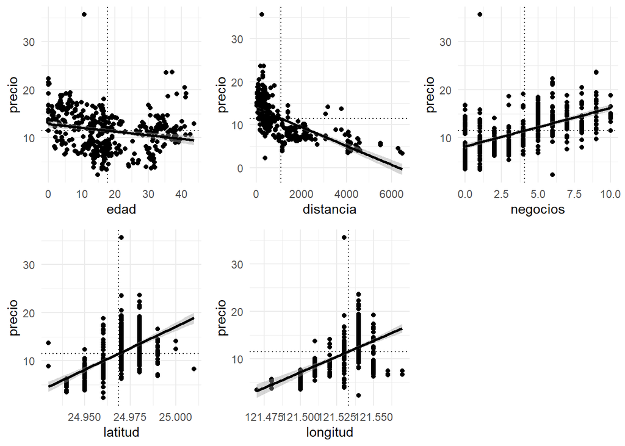

```r
# Se crea el promedio de las variables
promediosP <- colMeans(propiedades)

# Se crea las graficas
# grafica edad vs precio
c1 <- ggplot(propiedades, aes(edad, precio)) +
  geom_point() +
  geom_vline(xintercept=promediosP[1],linetype="dotted") +
  geom_hline(yintercept=promediosP[6],linetype="dotted") +
   geom_smooth(method = "lm", se = TRUE, color = "black") +
  theme_minimal()

# grafica distancia vs precio
c2 <- ggplot(propiedades, aes(distancia, precio)) +
  geom_point() +
  geom_vline(xintercept=promediosP[2],linetype="dotted") +
  geom_hline(yintercept=promediosP[6],linetype="dotted") +
   geom_smooth(method = "lm", se = TRUE, color = "black") +
  theme_minimal()

# grafica negocios vs precio
c3 <- ggplot(propiedades, aes(negocios, precio)) +
  geom_point() +
  geom_vline(xintercept=promediosP[3],linetype="dotted") +
  geom_hline(yintercept=promediosP[6],linetype="dotted") +
   geom_smooth(method = "lm", se = TRUE, color = "black") +
  theme_minimal()

# grafica negocios vs precio

c4 <- ggplot(propiedades, aes(latitud, precio)) +
  geom_point() +
  geom_vline(xintercept=promediosP[4],linetype="dotted") +
  geom_hline(yintercept=promediosP[6],linetype="dotted") +
   geom_smooth(method = "lm", se = TRUE, color = "black") +
  theme_minimal()

# grafica longitud vs precio

c5 <- ggplot(propiedades, aes(longitud, precio)) +
  geom_point() +
  geom_vline(xintercept=promediosP[5],linetype="dotted") +
  geom_hline(yintercept=promediosP[6],linetype="dotted") +
   geom_smooth(method = "lm", se = TRUE, color = "black") +
  theme_minimal()

grid.arrange(c1,c2,c3,c4,c5, ncol = 3, nrow = 2)
```

Se realizan los tests:

```r
# test Precio y edad
biNormTest <- mvn(data = propiedades[c(6,1)], mvnTest = "hz")
print(biNormTest$multivariateNormality$MVN)
```

```
## [1] "NO"
```

```r
# test Precio y distancia
biNormTest <- mvn(data = propiedades[c(6,2)], mvnTest = "hz")
print(biNormTest$multivariateNormality$MVN)
```

```
## [1] "NO"
```

```r
# test Precio y negocio
biNormTest <- mvn(data = propiedades[c(6,3)], mvnTest = "hz")
print(biNormTest$multivariateNormality$MVN)
```

```
## [1] "NO"
```

```r
# test Precio y latitud
biNormTest <- mvn(data = propiedades[c(6,4)], mvnTest = "hz")
print(biNormTest$multivariateNormality$MVN)
```

```
## [1] "NO"
```

```r
# test Precio y longitud
biNormTest <- mvn(data = propiedades[c(6,5)], mvnTest = "hz")
print(biNormTest$multivariateNormality$MVN)
```

```
## [1] "NO"
```

Por el resultado se observa que al no ser una distribución normal bivariada se procede a utilizar la correlación de Spearman

```r
cor.test(propiedades$precio,propiedades$edad,method="spearman")$p.value
```

```
## [1] 5.210699e-09
```

```r
cor.test(propiedades$precio,propiedades$distancia,method="spearman")$p.value
```

```
## [1] 2.824113e-83
```

```r
cor.test(propiedades$precio,propiedades$negocios,method="spearman")$p.value
```

```
## [1] 9.711186e-45
```

```r
cor.test(propiedades$precio,propiedades$latitud,method="spearman")$p.value
```

```
## [1] 3.42539e-39
```

```r
cor.test(propiedades$precio,propiedades$longitud,method="spearman")$p.value
```

```
## Warning in cor.test.default(propiedades$precio, propiedades$longitud, method =
## "spearman"): Cannot compute exact p-value with ties
```

```
## [1] 9.903455e-20
```

Las advertencias muestran empates en los datos para el calculo del P-valor, en tal sentido se utiliza un metodo robusto:

```r
# métodos robustos para manejar empates
cor.test(propiedades$precio,propiedades$edad,method="spearman",exact = FALSE)$p.value
```

```
## [1] 5.210699e-09
```

```r
cor.test(propiedades$precio,propiedades$distancia,method="spearman",exact = FALSE)$p.value
```

```
## [1] 2.824113e-83
```

```r
cor.test(propiedades$precio,propiedades$negocios,method="spearman",exact = FALSE)$p.value
```

```
## [1] 9.711186e-45
```

```r
cor.test(propiedades$precio,propiedades$latitud,method="spearman",exact = FALSE)$p.value
```

```
## [1] 3.42539e-39
```

```r
cor.test(propiedades$precio,propiedades$longitud,method="spearman",exact = FALSE)$p.value
```

```
## [1] 9.903455e-20
```

Por los resultados de los p-valores de las variables evaluadas contra la variable precio se rechaza la hipótesis nula y se concluye que existe correlación entre las variables.

Finalmente se presente un corplot para confirmar la relaciones entre las variables.

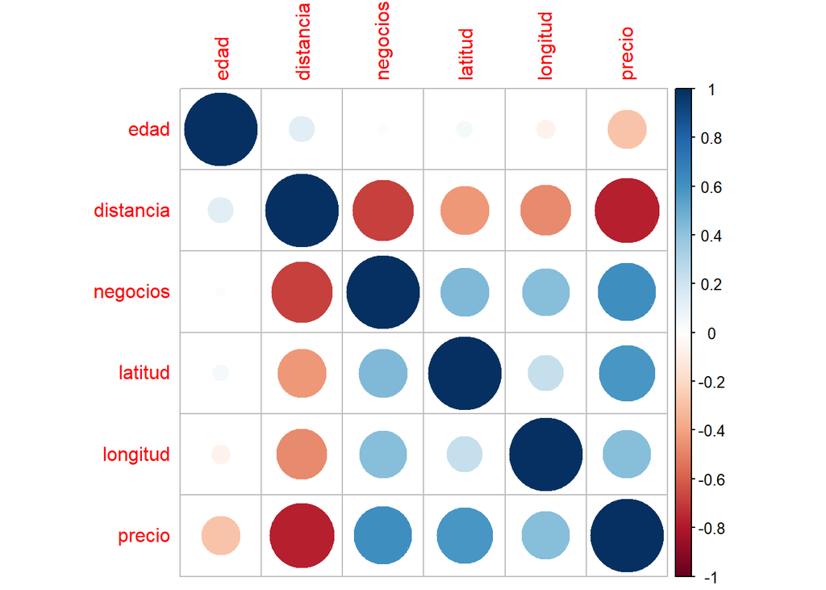

```r
library(corrplot)
corrplot(cor(propiedades,method="s"))
```

### (b)

Estudiar la linealidad de la relación precio-distancia.

```r
modelProp <- lm(precio ~ distancia, data = propiedades)

shapiro.test(modelProp$residuals)
```

```
##
##  Shapiro-Wilk normality test
##
## data:  modelProp$residuals
## W = 0.93207, p-value = 1.085e-12
```

No son normales los residuos.

### (c)

Estimar los coeficientes del modelo y realizar el análisis diagnóstico de los residuos del mismo. Utilizar para este análisis los gráficos de residuos versus valores ajustados, el qq-plot de los residuos, la grafica de residuos versus leverage.

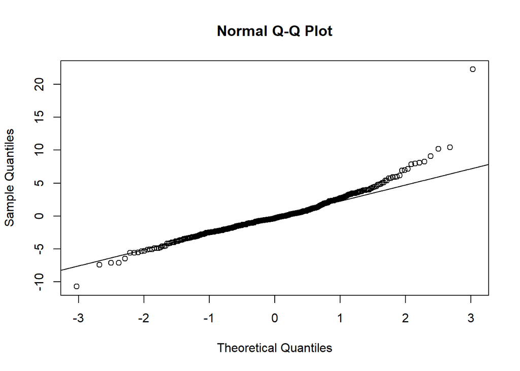

```r
prop2<-propiedades
prop2$prediccion <- modelProp$fitted.values
prop2$residuos <- modelProp$residuals

d1 <- ggplot(data = prop2, aes(x = prediccion, y = residuos)) +
  geom_point(aes(color = residuos)) +
  scale_color_gradient2(low = "blue3", mid = "grey", high = "red") +
  geom_hline(yintercept = 0) + geom_segment(aes(xend = prediccion, yend = 0), alpha = 0.2) +
  labs(title = "Distribución de los residuos", x = "predicción modelo", y = "residuo") +
  theme_bw() +
  theme(plot.title = element_text(hjust = 0.5), legend.position = "none")


d2<- ggplot(data = prop2, aes(x = residuos)) + geom_histogram(aes(y = ..density..)) +
  labs(title = "Histograma de los residuos") + theme_bw() +
  theme(plot.title = element_text(hjust = 0.5))

qqnorm(modelProp$residuals)
qqline(modelProp$residuals)
```

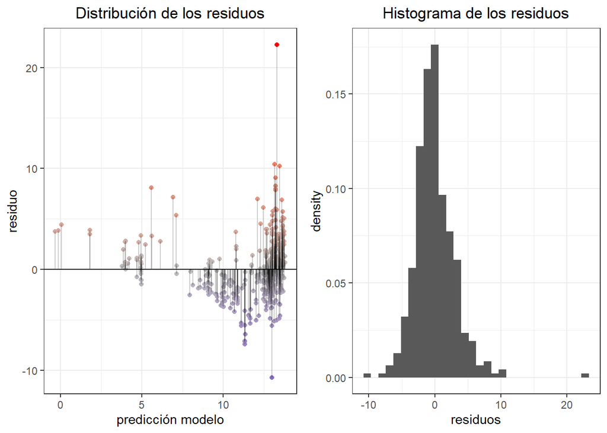

```r
grid.arrange(d1,d2,nrow = 1)
```

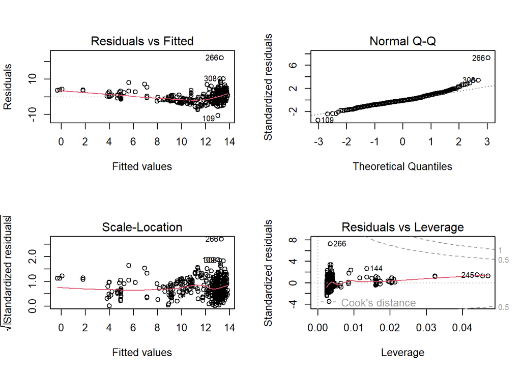

```r
par(mfrow=c(2,2))
plot(modelProp)
```

```r
par(mfrow=c(1,1))
```

### (d)

Aplicar los test de Durbin-Watson Breush-Pagan.

```r
#Durbin-Watson
library(lmtest)
dwtest(modelProp,alternative ="two.sided",iterations=1000)
```

```
##
##  Durbin-Watson test
##
## data:  modelProp
## DW = 2.1607, p-value = 0.1037
## alternative hypothesis: true autocorrelation is not 0
```

No hay evidencia suficiente para afirmar que hay autocorrelación en los residuos del modelo, ya que el valor p es mayor que el nivel de significancia comúnmente utilizado.

```r
# Test de Breush-Pagan
library(lmtest)
bptest(modelProp)
```

```
##
##  studentized Breusch-Pagan test
##
## data:  modelProp
## BP = 1.4397, df = 1, p-value = 0.2302
```

No se rechaza homocedasticidad.

### (e)

Analice la presencia de outlier y verifique si coinciden con los puntos influyentes.

```r
summary(influence.measures(model = modelProp))
```

```
## Potentially influential observations of
##   lm(formula = precio ~ distancia, data = propiedades) :
##
##     dfb.1_ dfb.dstn dffit   cov.r   cook.d hat
## 9   -0.10   0.23     0.24_*  1.03_*  0.03   0.03_*
## 12   0.15  -0.08     0.15    0.97_*  0.01   0.00
## 26  -0.05   0.12     0.13    1.02_*  0.01   0.02_*
## 31  -0.04   0.13     0.14    1.02_*  0.01   0.02_*
## 36   0.00  -0.01    -0.01    1.02_*  0.00   0.02_*
## 37  -0.01   0.02     0.02    1.02_*  0.00   0.02_*
## 44  -0.01   0.01     0.02    1.03_*  0.00   0.02_*
## 45   0.00   0.00     0.00    1.03_*  0.00   0.02_*
## 51  -0.08  -0.01    -0.12    0.98_*  0.01   0.00
## 54  -0.05   0.13     0.13    1.02_*  0.01   0.02_*
## 69  -0.01   0.05     0.05    1.02_*  0.00   0.02_*
```

[output cut: 38 more lines]

```r
dfbetas(modelProp)[,2]> 1
```

[output not shown]

[output cut: 9 more lines]

[output not shown]

```r
which(dfbetas(modelProp)[,2]>1)
```

```
## named integer(0)
```

```r
n<-length(propiedades$precio)
p<-length(modelProp$coefficients)
which(dffits(modelProp)>2 * sqrt(p / n))
```

```
##   9  12  31 101 112 144 162 216 224 245 251 266 308 340 343 375 385
##   9  12  31 101 112 144 162 216 224 245 251 266 308 340 343 375 385
```

Otros puntos influyentes: puntos de alto leverage y distancia de Cook

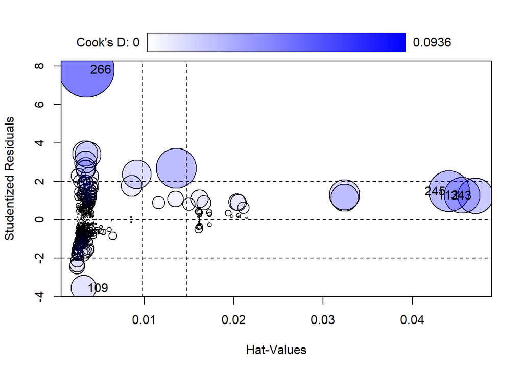

|  | StudRes | Hat | CookD |
| --- | --- | --- | --- |
| 109 | -3.558753 | 0.003177114 | 0.01962043 |
| 112 | 1.283280 | 0.045548798 | 0.03923255 |
| 245 | 1.484990 | 0.044098196 | 0.05071549 |
| 266 | 7.815835 | 0.003504965 | 0.09361073 |
| 343 | 1.250954 | 0.047050778 | 0.03857867 |

```r
influencePlot(model = modelProp)
```

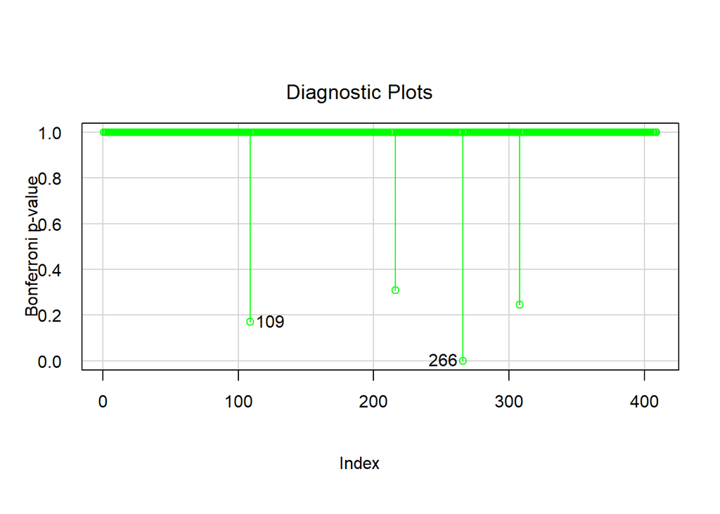

```r
influenceIndexPlot(modelProp, vars='Bonf', las=1,col='green')
```

```r
outlierTest(modelProp)
```

```
##     rstudent unadjusted p-value Bonferroni p
## 266 7.815835         4.7349e-14   1.9366e-11
```

```r
#leverage
hatvalues(modelProp)
```

[output not shown]

[output cut: 83 more lines]

[output not shown]

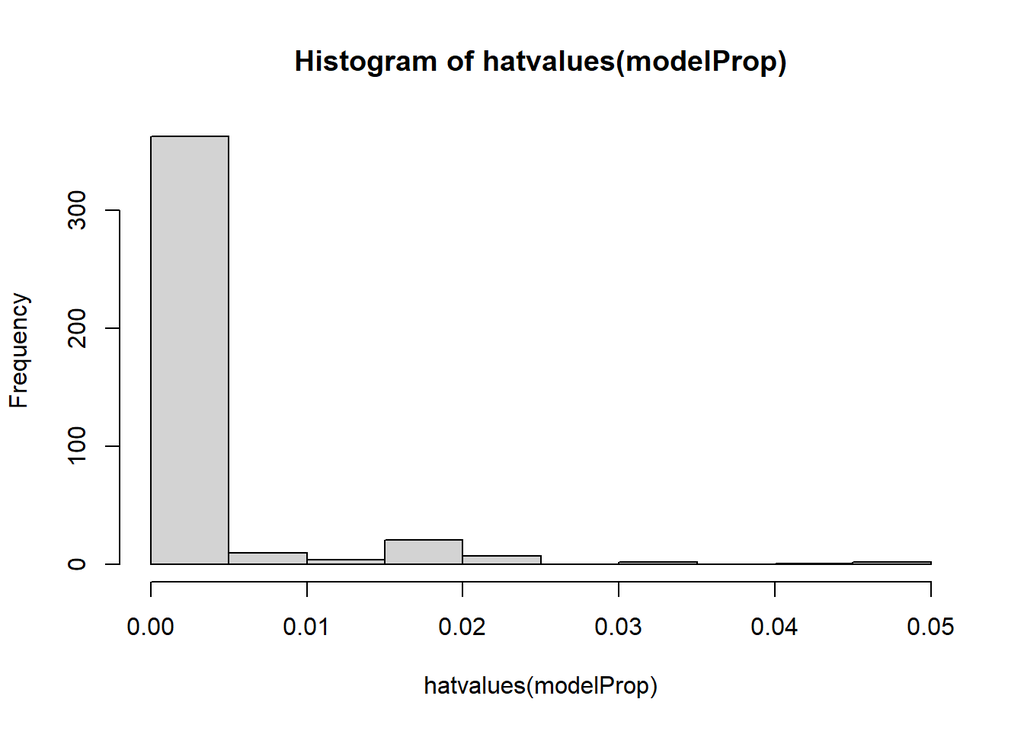

```r
hist(hatvalues(modelProp))
```

```r
lev<-hatvalues(modelProp)

#un criterio (mayores que 0.2)

which(lev>0.2)
```

```
## named integer(0)
```

```r
#un criterio mas exigente
n<-length(propiedades$precio)
p<-length(modelProp$coefficients)
which(lev>2*p/n)
```

```
##   9  26  31  36  37  44  45  54  69  83  85 112 113 144 150 151 158 166 172 176
##   9  26  31  36  37  44  45  54  69  83  85 112 113 144 150 151 158 166 172 176
## 179 185 190 222 227 228 245 251 294 316 325 327 343 378 380 390 405
## 179 185 190 222 227 228 245 251 294 316 325 327 343 378 380 390 405
```

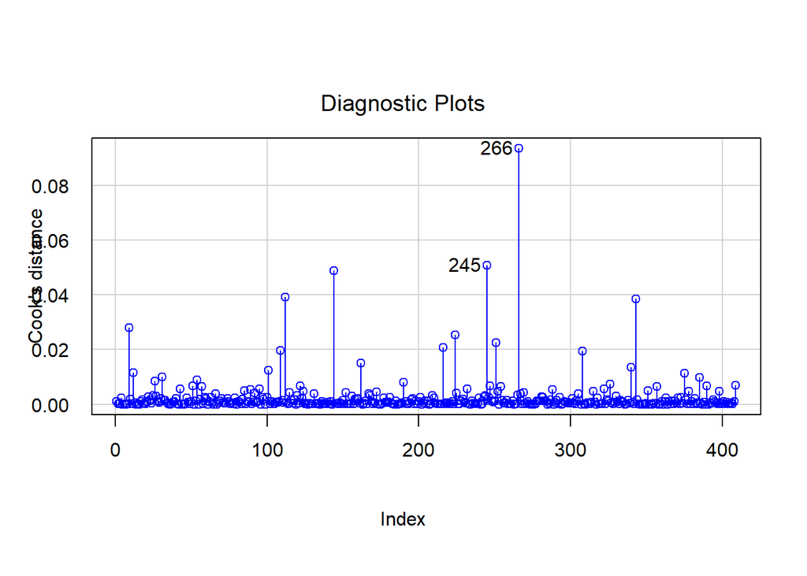

```r
#distancias de cook
dcook<-cooks.distance(modelProp)
influenceIndexPlot(modelProp, vars='Cook', las=1,col='blue')
```

```r
which(dcook>4/n)
```

```
##   9  12  31 101 109 112 144 162 216 224 245 251 266 308 340 343 375 385
##   9  12  31 101 109 112 144 162 216 224 245 251 266 308 340 343 375 385
```

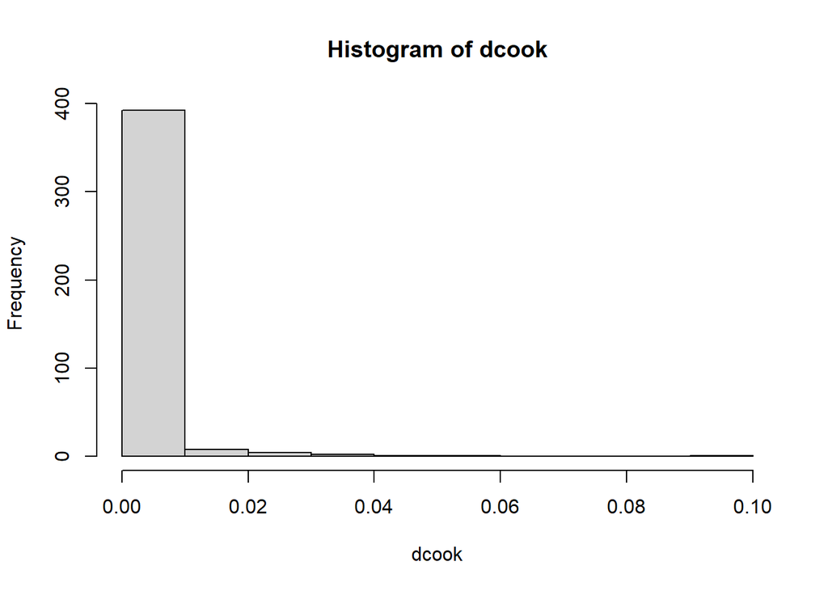

```r
hist(dcook)
```

```r
#punto de corte
corted<-qf(0.5,2,n-2)
which(dcook>corted)
```

```
## named integer(0)
```

Se observa que el punto outlier que a su vez es punto influyente es el 266 y los puntos influyentes del conjunto de datos son 109, 112, 245 y 343.

# 1.5. Cuadrados Mínimos Ponderados

## Ejercicio 1.6.

En la base estudio.xlsx se encuentran registradas las horas de estudios referidas por un conjunto de estudiantes y su calificación en la evaluación final.

```r
# se carga la base
baseeje16="C:/Users/Josvaldes/Documents/Maestria/Austral/1ano/regresionAvanzada/TPRegresion/TPRegresion/estudio.csv"
estudioseje16 <- read.csv(baseeje16,header = TRUE, sep = ";")

estudioseje16
```

| horas_estudio | puntaje |
| --- | --- |
| 1.0 | 28 |
| 1.0 | 38 |
| 1.5 | 45 |
| 1.5 | 44 |
| 2.0 | 52 |
| 2.0 | 50 |
| 2.0 | 46 |
| 2.5 | 52 |
| 2.5 | 53 |
| 3.0 | 72 |

[output cut: 27 more lines]

### (a)

Ajuste un modelo de regresión simple para estimar la nota final en función de las horas dedicadas al estudio.

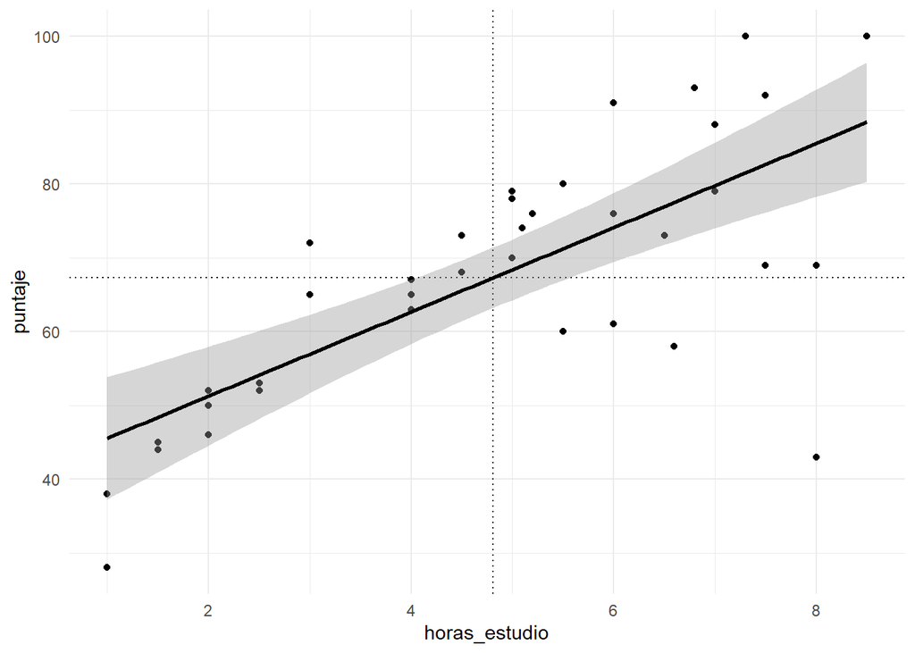

```r
model16 <- lm(puntaje ~ horas_estudio, data = estudioseje16)
promedios16 <- colMeans(estudioseje16)
ggplot(estudioseje16, aes(horas_estudio, puntaje)) +
  geom_point() +
  geom_vline(xintercept=promedios16[1],linetype="dotted") +
  geom_hline(yintercept=promedios16[2],linetype="dotted") +
   geom_smooth(method = "lm", se = TRUE, color = "black") +
  theme_minimal()
```

### (b)

Estudie el cumplimiento de los supuestos del modelo, gráfica y analíticamente.

Gráficamente:

En el punto a) se observa que el modelo lineal y su intervalo de confianza presentan puntos que pueden ser outliers e influyentes, por lo tanto, no es un modelo muy confiable por algunas observaciones.

analíticamente:

Se valida la binormalidad

```r
biNormTest16 <- mvn(data = estudioseje16, mvnTest = "hz")
biNormTest16$multivariateNormality
```

| Test | HZ | p value | MVN |
| --- | --- | --- | --- |
| Henze-Zirkler | 1.239238 | 0.00368416 | NO |

Por la respuesta obtenida se aplica el test de Spearman

```r
corTest16 <- cor.test(estudioseje16$horas_estudio, estudioseje16$puntaje, method = "spearman",exact = FALSE)
corTest16
```

```
##
##  Spearman's rank correlation rho
##
## data:  estudioseje16$horas_estudio and estudioseje16$puntaje
## S = 2827.4, p-value = 7.18e-06
## alternative hypothesis: true rho is not equal to 0
## sample estimates:
##      rho
## 0.664846
```

Por el resultado del p-valor de la variable evaluada contra la variable hora de estudio se rechaza la hipótesis nula y se concluye que existe correlación entre las variables.

```r
summary(model16)
```

```
##
## Call:
## lm(formula = puntaje ~ horas_estudio, data = estudioseje16)
##
## Residuals:
##     Min      1Q  Median      3Q     Max
## -42.506  -4.395   1.623   8.204  18.491
##
## Coefficients:
##               Estimate Std. Error t value Pr(>|t|)
## (Intercept)    39.8305     4.9007   8.127 1.43e-09 ***
## horas_estudio   5.7094     0.9288   6.147 4.94e-07 ***
## ---
## Signif. codes:  0 '***' 0.001 '**' 0.01 '*' 0.05 '.' 0.1 ' ' 1
##
## Residual standard error: 12.24 on 35 degrees of freedom
## Multiple R-squared:  0.5192, Adjusted R-squared:  0.5054
## F-statistic: 37.79 on 1 and 35 DF,  p-value: 4.943e-07
```

Los resultados del modelo lineal indican que la variable horas_estudio es significativa y el modelo logra explicar el 50% de la variable respuesta, el modelo por el test F muestra que es significativo.

**Normalidad de los residuos**

```r
shapiro.test(model16$residuals)
```

```
##
##  Shapiro-Wilk normality test
##
## data:  model16$residuals
## W = 0.92105, p-value = 0.01196
```

El test de normalidad de Shapiro indica que no hay normalidad de los residuos, dado que se rechaza la hipótesis nula de normalidad.

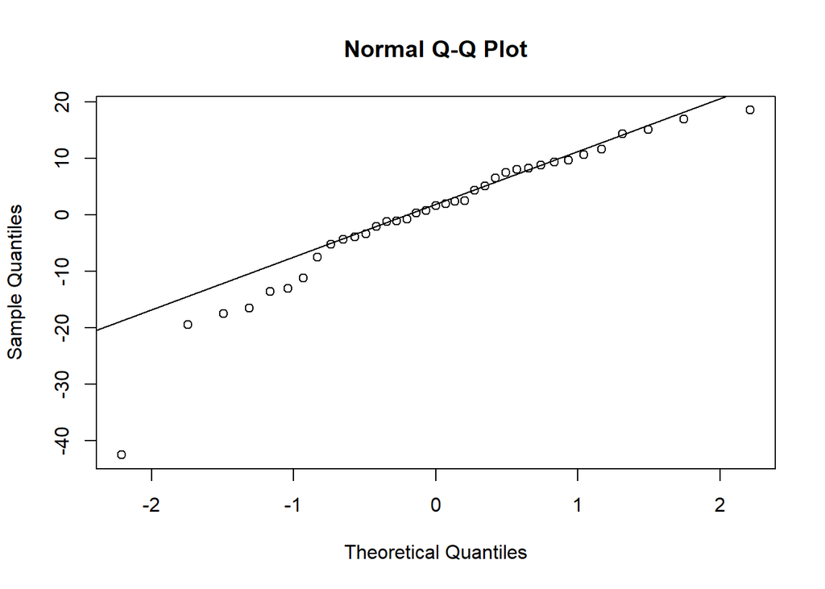

```r
qqnorm(model16$residuals)
qqline(model16$residuals)
```

Se observan puntos en los extremos que se alejan de la recta, esto puede deber ser a puntos outliers.

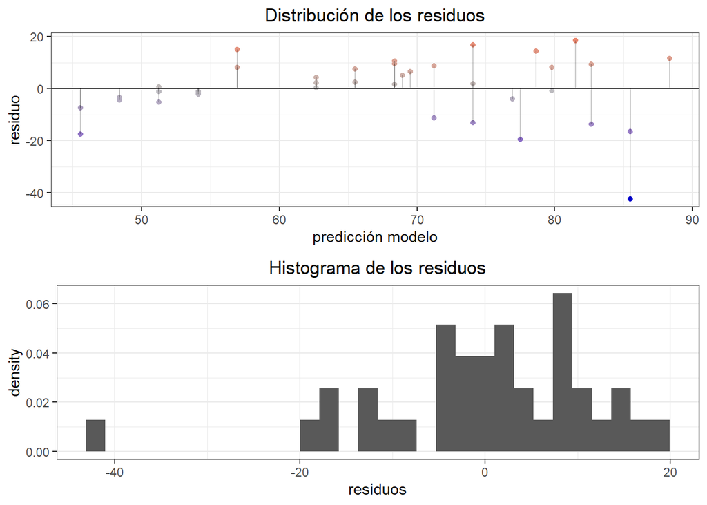

```r
model16b <- data.frame(prediccion = model16$fitted.values,
                       residuos = model16$residuals)


d1_16 <- ggplot(data = model16b, aes(x = prediccion, y = residuos)) +
  geom_point(aes(color = residuos)) +
  scale_color_gradient2(low = "blue3", mid = "grey", high = "red") +
  geom_hline(yintercept = 0) + geom_segment(aes(xend = prediccion, yend = 0), alpha = 0.2) +
  labs(title = "Distribución de los residuos", x = "predicción modelo", y = "residuo") +
  theme_bw() +
  theme(plot.title = element_text(hjust = 0.5), legend.position = "none")


d2_16<- ggplot(data = model16b, aes(x = residuos)) + geom_histogram(aes(y = ..density..)) +
  labs(title = "Histograma de los residuos") + theme_bw() +
  theme(plot.title = element_text(hjust = 0.5))

grid.arrange(d1_16,d2_16,nrow = 2)
```

Se podría pensar en alguna forma cónica de los residuos.

**Validación de si los residuos estan aoutocorrelacionados**

```r
#Durbin-Watson
dwtest(model16,alternative ="two.sided",iterations=1000)
```

```
##
##  Durbin-Watson test
##
## data:  model16
## DW = 1.8264, p-value = 0.477
## alternative hypothesis: true autocorrelation is not 0
```

**heterocedasticidad de los residuos**

```r
bptest(model16)
```

```
##
##  studentized Breusch-Pagan test
##
## data:  model16
## BP = 4.781, df = 1, p-value = 0.02877
```

El valor p de 0.02877 indica que hay evidencia suficiente para rechazar la hipótesis nula de que no hay heteroscedasticidad en el modelo. En otras palabras, se sugiere que existe heteroscedasticidad en los residuos.

**Outliers**

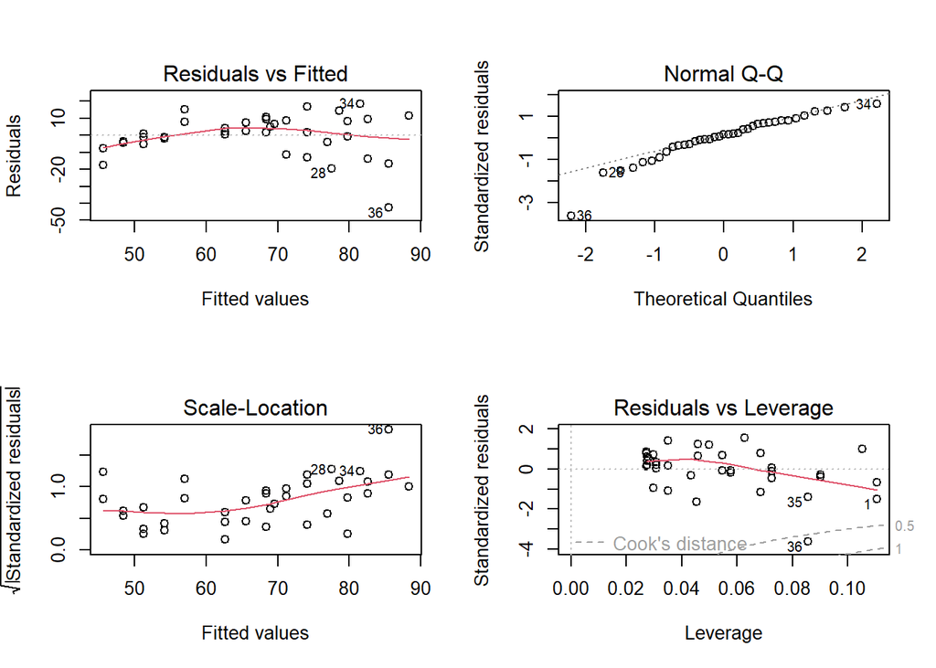

```r
par(mfrow=c(2,2))
plot(model16)
```

```r
par(mfrow=c(1,1))
```

```r
summary(influence.measures(model = model16))
```

```
## Potentially influential observations of
##   lm(formula = puntaje ~ horas_estudio, data = estudioseje16) :
##
##    dfb.1_ dfb.hrs_ dffit   cov.r   cook.d hat
## 36  0.73  -1.15_*  -1.39_*  0.45_*  0.62   0.09
```

Se observa que el punto 36 puede ser outlier y/o influyente.

```r
outlierTest(model16)
```

```
##     rstudent unadjusted p-value Bonferroni p
## 36 -4.530962          6.908e-05     0.002556
```

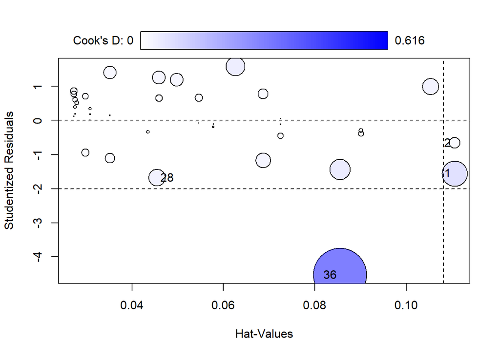

|  | StudRes | Hat | CookD |
| --- | --- | --- | --- |
| 1 | -1.5489171 | 0.11057691 | 0.14340334 |
| 2 | -0.6474729 | 0.11057691 | 0.02649941 |
| 28 | -1.6723453 | 0.04544423 | 0.06332250 |
| 36 | -4.5309623 | 0.08554262 | 0.61631903 |

```r
influencePlot(model = model16)
```

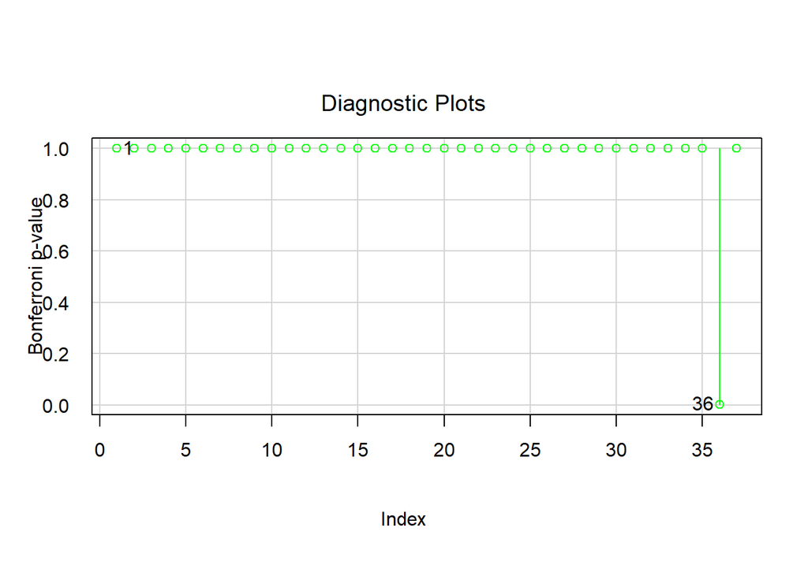

```r
influenceIndexPlot(model16, vars='Bonf', las=1,col='green')
```

Se concluye que el punto 36 es un outlier.

### (c)

Ajuste un modelo de mínimos cuadrados ponderados definiendo los pesos de tal manera que las observaciones con menor varianza tengan más peso.

Se crea un vector de pesos:

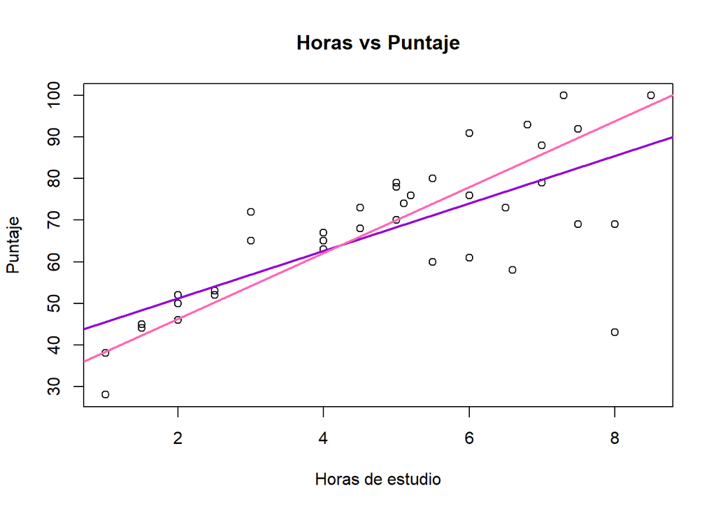

```r
ww<-1 / lm(abs(model16$residuals) ~ model16$fitted.values)$fitted.values^2

plot(estudioseje16$horas_estudio,estudioseje16$puntaje,xlab="Horas de estudio",ylab="Puntaje",
     main="Horas vs Puntaje")

abline(model16,col="darkviolet",lwd=2)

model16_ww<- lm(puntaje ~ horas_estudio, data = estudioseje16,weights =ww)
abline(model16_ww,col="hotpink",lwd=2)
```

Se observa un cambio de la pendiente de la recta de regresión, esto basado en los pesos asignados.

### (d)

Realice el análisis diagnóstico del segundo modelo ajustado.

**Normalidad de los residuos**

```r
shapiro.test(model16_ww$residuals)
```

```
##
##  Shapiro-Wilk normality test
##
## data:  model16_ww$residuals
## W = 0.82071, p-value = 3.498e-05
```

No están normalmente distribuidos los residuos.

**Independencia de los residuos**

```r
#dwtest(model16_ww,alternative ="two.sided",iterations=1000)

#salida
#Error in dwtest(model16_ww, alternative = "two.sided", iterations = 1000) :
#weighted regressions are not supported
```

Por el error se intenta validar la independencia con otro test.

```r
# Realizar el test de Ljung-Box
ljung_box_test <- Box.test(model16_ww$residuals, lag = 12, type = "Ljung-Box")

# Imprimir los resultados
ljung_box_test
```

```
##
##  Box-Ljung test
##
## data:  model16_ww$residuals
## X-squared = 15.761, df = 12, p-value = 0.2024
```

El valor p de 0.2024 indica que no hay suficiente evidencia para rechazar la hipótesis nula de no autocorrelación en los residuos. En otras palabras, no se encuentra evidencia significativa de autocorrelación en los residuos del modelo.

**Homocedasticidad**

```r
bptest(model16_ww)
```

```
##
##  studentized Breusch-Pagan test
##
## data:  model16_ww
## BP = 0.042377, df = 1, p-value = 0.8369
```

Los residuos son homocedasticos

**Resumen**

- Normalidad de residuos: NO
- Independencia: SÍ
- Homocedasticidad: SÍ

### (e)

Compare ambos ajustes realizados y concluya.

```r
summary(model16_ww)
```

```
##
## Call:
## lm(formula = puntaje ~ horas_estudio, data = estudioseje16, weights = ww)
##
## Weighted Residuals:
##     Min      1Q  Median      3Q     Max
## -4.1319 -0.1878  0.3319  0.7847  3.0358
##
## Coefficients:
##               Estimate Std. Error t value Pr(>|t|)
## (Intercept)    30.4831     2.3204   13.14 4.32e-15 ***
## horas_estudio   7.9253     0.7407   10.70 1.40e-12 ***
## ---
## Signif. codes:  0 '***' 0.001 '**' 0.01 '*' 0.05 '.' 0.1 ' ' 1
##
## Residual standard error: 1.397 on 35 degrees of freedom
## Multiple R-squared:  0.7658, Adjusted R-squared:  0.7592
## F-statistic: 114.5 on 1 and 35 DF,  p-value: 1.404e-12
```

Se observa que el modelo con pesos explica la variable respuesta un 75,92% a diferencia del modelo inicial que explicaba el 50.54%, de esta forma se observa que el vector de pesos bajo la influencia de los valores extremos.

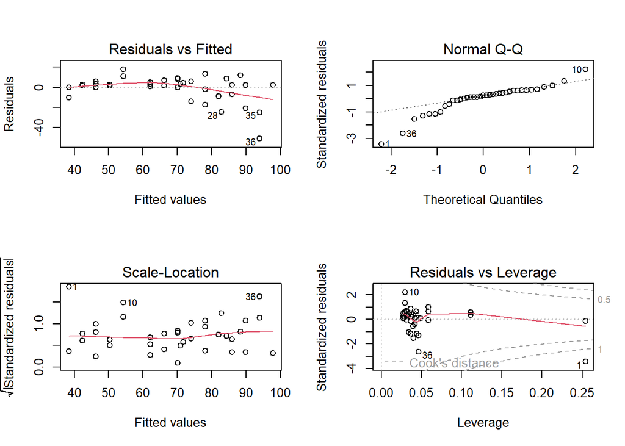

```r
par(mfrow=c(2,2))
plot(model16_ww)
```

```r
par(mfrow=c(1,1))
```